# Survival_Analysis_CustomerChurn

Summary

Survival analysis is a statistical method used to estimate the time until an event of interest occurs, such as death, failure, or relapse. It accounts for censored data, where the event has not occurred for some subjects during the observation period, allowing for more accurate predictions and insights into the factors influencing the timing of events.

In this notebook, survival analysis is applied for Telco Customer Churn data and to Predict the customer that will likely stop business with the company and. Non-parametric and parametric techniques are applied including Kaplan-Meier, Weibull and Cox Hazard.

Python functions and data files to run this notebook are in my [Github](https://github.com/MehdiRezvandehy/Abstract-Title-Prediction-by-Fine-Tuned-T5.git)

```python
import warnings
warnings.filterwarnings('ignore')
from profiling import *
import pandas as pd
pd.set_option('display.max_colwidth', None)
pd.set_option('display.max_columns', None)

import streamlit as st
import matplotlib.pyplot as plt
import numpy as np
from sklearn.model_selection import StratifiedShuffleSplit
import pickle
from sklearn.preprocessing import OrdinalEncoder
from sklearn.preprocessing import StandardScaler, OneHotEncoder
from sklearn.ensemble import RandomForestClassifier
from sklearn.model_selection import train_test_split
from sklearn.pipeline import Pipeline
from sklearn import set_config
from sklearn.compose import ColumnTransformer
from sklearn.impute import SimpleImputer
from lifelines.plotting import qq_plot
from lifelines import LogLogisticFitter
from lifelines import CoxPHFitter

from sklearn.preprocessing import FunctionTransformer
```

# Introduction

## What is survival analysis?

Survival analysis is a statistical approach for analyzing the expected duration until one or more events occur, such as death, failure, or relapse. It is widely used in clinical trials, reliability engineering, and various fields where the time to an event is of interest. The analysis typically involves methods for handling censored data, where the event has not occurred for some subjects during the study period. Key techniques include Kaplan-Meier estimates, Cox proportional hazards models, and parametric survival models.

- Example
  - Time until loan default
  - Time until equipment failure
  - Time until a tree's first fruit
  - Time until free-trial users convert to subscribers

The definition of Event, Survival and Survival duration are:

> **Event:** Equipment failure, loan default, disease recurrence, user conversion, or other significant experience of interest.

> **Survival:** The event of interest has not occurred.

> **Survival duration:** Time until the event of interest occurs or until the end of our observations.

## Time to Event

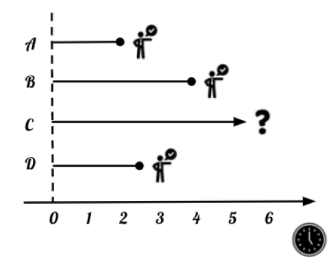

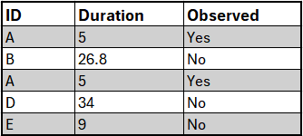

> **Event:** Must be clear and unambiguous, and cannot partially occur.

> There should be ample data where the event does happen for survival analysis to be effective.

## Censoring

The Censoring problem occurs when the survival time is **only partially known.**

How Does Censoring Happen?

> The event has **not yet occurred by the end of the observation period**. Example: A free trial user has not converted to a paid user by the end of an experiment.

> The individual's data is missing **due to dropout or loss of contact**. Example: A free trial user declines to share data for the experiment.

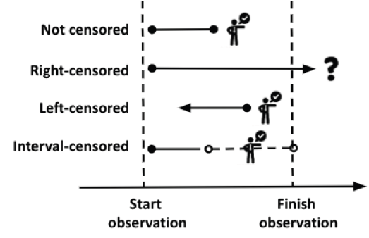

> **Not Censored**: The event occurred, and the survival duration is known.

> **Right-Censored**: The survival duration exceeds the observed duration.

> **Left-Censored**: The survival duration is less than the observed duration.

> **Interval-Censored**: The survival duration falls within a certain range but is not exactly known.

### Why is Censoring a Challenge?

Censoring can complicate survival analysis for several reasons:

- **Incomplete Data:** Censoring leads to incomplete information about the survival time, making it difficult to accurately estimate the true survival distribution.
- **Bias:** If censoring is not random and is related to the event of interest, it can introduce bias into the analysis, leading to inaccurate conclusions.
- **Reduced Statistical Power:** Censoring reduces the number of events observed, which can diminish the statistical power of the study and make it harder to detect significant effects.
- **Complex Analysis:** Handling censored data requires more sophisticated statistical methods and models, which can be more complex to implement and interpret.

## Survival Function

The survival function is a fundamental concept in survival analysis. Here’s a detailed explanation:

1. **Does Not Impute Censored Data:** The survival function does not attempt to guess or fill in the missing data for individuals whose event time is censored. Instead, it uses the available data to estimate survival probabilities without making assumptions about the exact time of censored events.
1. **Models the Probability of a Survival Duration Being Larger Than a Certain Value:** The survival function, denoted as $𝑆(𝑡)$, represents the probability that an individual survives longer than a specified time. Mathematically, it is defined as:

   $S(t)=P(T>t)$
   - $T$ : when the event of interest occurs
   - $t$: any point in time during an observation
   - $S(t)$: models the probability that the event of interest happens after t
   - $P(T > t)$: the survival probability

## Checking Data for Censoring

Is there a way to identify which data points are censored?

**Step 1) Check for Censoring Columns**

Look for columns in your dataset that indicate whether an observation is censored. These columns are often preprocessed and labeled, for example, as censored or event_observed.

**Step 2) Check the Proportion of Censored Data**

Determine the proportion of data points that are censored. A common rule of thumb is to ensure that less than **50%** of your data is censored. Excessive censoring can reduce the reliability and power of your analysis.

**Step 3) Investigate the Causes of Censoring**

Examine the reasons behind the censoring to confirm that it is non-informative and random. Non-informative censoring means that the fact an observation is censored does not provide any information about its survival time. If the causes of censoring are related to the survival time, it can bias the results.

In summary, to identify and assess censoring in your data:

Identify Censoring Indicators: Look for specific columns marking censored data. Evaluate the Proportion: Ensure the proportion of censored data is manageable. Assess Censoring Causes: Confirm that censoring is random and non-informative to avoid bias.

## Non-parametric vs parametric models

**Non-Parametric Modeling**

> Makes no assumptions about the shape of the data. Parametric Modeling

**Makes some assumptions about the shape of the data.**

> Described with a limited set of parameters. For example, the survival curve may be assumed to follow an exponential distribution.

# Telco Customer Churn

## Data Processing

Telco Customer Churn data set is retrieved from [Kaggle](https://www.kaggle.com/datasets/blastchar/telco-customer-churn/data). The Context is to "Predict the customer that will likely stop business with the company and subsequently apply strategies to retain those customers.

- [Notebook](https://www.kaggle.com/code/brunods10/predicting-customer-churn-with-survival-analysis/notebook)

```python
df_telco_churn = pd.read_csv('WA_Fn-UseC_-Telco-Customer-Churn.csv')
df_telco_churn
```

|  | customerID | gender | SeniorCitizen | Partner | Dependents | tenure | PhoneService | MultipleLines | InternetService | OnlineSecurity | OnlineBackup | DeviceProtection | TechSupport | StreamingTV | StreamingMovies | Contract | PaperlessBilling | PaymentMethod | MonthlyCharges | TotalCharges | Churn |
| --- | --- | --- | --- | --- | --- | --- | --- | --- | --- | --- | --- | --- | --- | --- | --- | --- | --- | --- | --- | --- | --- |
| 0 | 7590-VHVEG | Female | 0 | Yes | No | 1 | No | No phone service | DSL | No | Yes | No | No | No | No | Month-to-month | Yes | Electronic check | 29.85 | 29.85 | No |
| 1 | 5575-GNVDE | Male | 0 | No | No | 34 | Yes | No | DSL | Yes | No | Yes | No | No | No | One year | No | Mailed check | 56.95 | 1889.5 | No |
| 2 | 3668-QPYBK | Male | 0 | No | No | 2 | Yes | No | DSL | Yes | Yes | No | No | No | No | Month-to-month | Yes | Mailed check | 53.85 | 108.15 | Yes |
| 3 | 7795-CFOCW | Male | 0 | No | No | 45 | No | No phone service | DSL | Yes | No | Yes | Yes | No | No | One year | No | Bank transfer (automatic) | 42.30 | 1840.75 | No |
| 4 | 9237-HQITU | Female | 0 | No | No | 2 | Yes | No | Fiber optic | No | No | No | No | No | No | Month-to-month | Yes | Electronic check | 70.70 | 151.65 | Yes |
| ... | ... | ... | ... | ... | ... | ... | ... | ... | ... | ... | ... | ... | ... | ... | ... | ... | ... | ... | ... | ... | ... |
| 7038 | 6840-RESVB | Male | 0 | Yes | Yes | 24 | Yes | Yes | DSL | Yes | No | Yes | Yes | Yes | Yes | One year | Yes | Mailed check | 84.80 | 1990.5 | No |
| 7039 | 2234-XADUH | Female | 0 | Yes | Yes | 72 | Yes | Yes | Fiber optic | No | Yes | Yes | No | Yes | Yes | One year | Yes | Credit card (automatic) | 103.20 | 7362.9 | No |
| 7040 | 4801-JZAZL | Female | 0 | Yes | Yes | 11 | No | No phone service | DSL | Yes | No | No | No | No | No | Month-to-month | Yes | Electronic check | 29.60 | 346.45 | No |
| 7041 | 8361-LTMKD | Male | 1 | Yes | No | 4 | Yes | Yes | Fiber optic | No | No | No | No | No | No | Month-to-month | Yes | Mailed check | 74.40 | 306.6 | Yes |
| 7042 | 3186-AJIEK | Male | 0 | No | No | 66 | Yes | No | Fiber optic | Yes | No | Yes | Yes | Yes | Yes | Two year | Yes | Bank transfer (automatic) | 105.65 | 6844.5 | No |

7043 rows × 21 columns

- **Content**

  Each row represents a customer, each column contains customer’s attributes described on the column Metadata.

The data set includes information about:

- Customers who left within the last month – the column is called Churn
- Services that each customer has signed up for – phone, multiple lines, internet, online security, online backup, device protection, tech support, and streaming TV and movies
- Customer account information – how long they’ve been a customer, contract, payment method, paperless billing, monthly charges, and total charges
- Demographic info about customers – gender, age range, and if they have partners and dependents

The main aim is **to apply survival analysis for customer churn**

```python
df_telco_churn
```

|  | customerID | gender | SeniorCitizen | Partner | Dependents | tenure | PhoneService | MultipleLines | InternetService | OnlineSecurity | OnlineBackup | DeviceProtection | TechSupport | StreamingTV | StreamingMovies | Contract | PaperlessBilling | PaymentMethod | MonthlyCharges | TotalCharges | Churn |
| --- | --- | --- | --- | --- | --- | --- | --- | --- | --- | --- | --- | --- | --- | --- | --- | --- | --- | --- | --- | --- | --- |
| 0 | 7590-VHVEG | Female | 0 | Yes | No | 1 | No | No phone service | DSL | No | Yes | No | No | No | No | Month-to-month | Yes | Electronic check | 29.85 | 29.85 | No |
| 1 | 5575-GNVDE | Male | 0 | No | No | 34 | Yes | No | DSL | Yes | No | Yes | No | No | No | One year | No | Mailed check | 56.95 | 1889.5 | No |
| 2 | 3668-QPYBK | Male | 0 | No | No | 2 | Yes | No | DSL | Yes | Yes | No | No | No | No | Month-to-month | Yes | Mailed check | 53.85 | 108.15 | Yes |
| 3 | 7795-CFOCW | Male | 0 | No | No | 45 | No | No phone service | DSL | Yes | No | Yes | Yes | No | No | One year | No | Bank transfer (automatic) | 42.30 | 1840.75 | No |
| 4 | 9237-HQITU | Female | 0 | No | No | 2 | Yes | No | Fiber optic | No | No | No | No | No | No | Month-to-month | Yes | Electronic check | 70.70 | 151.65 | Yes |
| ... | ... | ... | ... | ... | ... | ... | ... | ... | ... | ... | ... | ... | ... | ... | ... | ... | ... | ... | ... | ... | ... |
| 7038 | 6840-RESVB | Male | 0 | Yes | Yes | 24 | Yes | Yes | DSL | Yes | No | Yes | Yes | Yes | Yes | One year | Yes | Mailed check | 84.80 | 1990.5 | No |
| 7039 | 2234-XADUH | Female | 0 | Yes | Yes | 72 | Yes | Yes | Fiber optic | No | Yes | Yes | No | Yes | Yes | One year | Yes | Credit card (automatic) | 103.20 | 7362.9 | No |
| 7040 | 4801-JZAZL | Female | 0 | Yes | Yes | 11 | No | No phone service | DSL | Yes | No | No | No | No | No | Month-to-month | Yes | Electronic check | 29.60 | 346.45 | No |
| 7041 | 8361-LTMKD | Male | 1 | Yes | No | 4 | Yes | Yes | Fiber optic | No | No | No | No | No | No | Month-to-month | Yes | Mailed check | 74.40 | 306.6 | Yes |
| 7042 | 3186-AJIEK | Male | 0 | No | No | 66 | Yes | No | Fiber optic | Yes | No | Yes | Yes | Yes | Yes | Two year | Yes | Bank transfer (automatic) | 105.65 | 6844.5 | No |

7043 rows × 21 columns

```python
df_telco_churn = df_telco_churn.reindex(np.random.permutation(df_telco_churn.index))
df_telco_churn.reset_index(inplace=True, drop=True) # Reset index
```

```python
df_telco_churn.columns
```

```
Index(['customerID', 'gender', 'SeniorCitizen', 'Partner', 'Dependents',
       'tenure', 'PhoneService', 'MultipleLines', 'InternetService',
       'OnlineSecurity', 'OnlineBackup', 'DeviceProtection', 'TechSupport',
       'StreamingTV', 'StreamingMovies', 'Contract', 'PaperlessBilling',
       'PaymentMethod', 'MonthlyCharges', 'TotalCharges', 'Churn'],
      dtype='object')
```

```python
# check if there is duplicates or not
assert len(df_telco_churn['customerID'].drop_duplicates()) == len(df_telco_churn['customerID'])
```

```python
#df_telco_churn.drop(['customerID'], axis=1, inplace=True)
df_telco_churn['SeniorCitizen'] = df_telco_churn['SeniorCitizen'].replace({1: 'Yes', 0: 'No'})
```

```python
df_telco_churn['TotalCharges'] = pd.to_numeric(df_telco_churn['TotalCharges'], errors='coerce').fillna(0)
df_telco_churn['MonthlyCharges'] = pd.to_numeric(df_telco_churn['MonthlyCharges'], errors='coerce').fillna(0)
```

```python
# correct wrongly assign dtypes in Pandas DataFrame
feat_num = []
feat_obj = []
for iclm in df_telco_churn.columns.to_list():
    if iclm != 'customerID':
        if  df_telco_churn[iclm].dtypes=='dbdate':
            df_telco_churn[iclm] = [int(i.strftime('%y%j')) for i in df_telco_churn[iclm]] # convert 'dbdate' to Julian date
            feat_num.append(iclm)
        else:
            try:
                pd.to_numeric(df_telco_churn[iclm])
                feat_num.append(iclm)
            except (ValueError, TypeError):
                feat_obj.append(iclm)

df_telco_churn[feat_num] = df_telco_churn[feat_num].astype(float)
clmns = feat_num + feat_obj
```

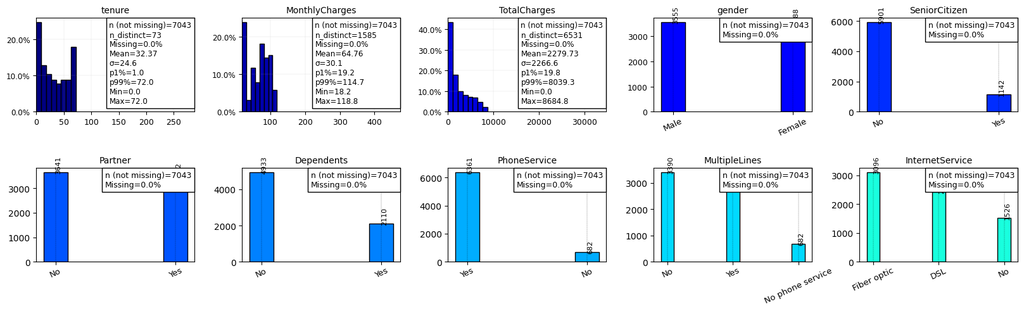

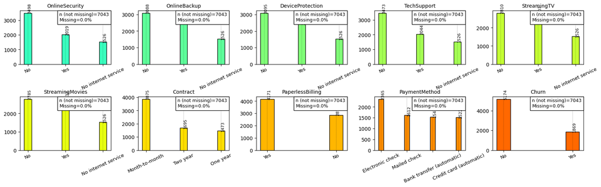

```python
font = {'size'   : 9}
plt.rc('font', **font)
colors_map = plt.cm.get_cmap('jet')
colors = colors_map(np.linspace(0,0.8,len(clmns)))

#
miss_n = [None]*len(feat_num)
miss_p = [None]*len(feat_num)
p1 = [None]*len(feat_num)
p99 = [None]*len(feat_num)
sd_num = [None]*len(feat_num)
#
nfig1 = np.arange(0, len(clmns),10)
nfig2 = np.arange(10, len(clmns)+10,10)
ino = 0
num_count = 0
for ig in zip(nfig1, nfig2):
    in_ = 0
    fig, ax = plt.subplots(figsize=(20, 5), dpi= 100, facecolor='w', edgecolor='k')
    ax.axis('off')  # This turns off the axis lines and labels
    for ir in range(ig[0],ig[1]):
        if ir < len(clmns):
            ax1 = plt.subplot(2,5,in_+1)

            if clmns[ir] in feat_num:
                val = df_telco_churn[clmns[ir]]
                _,_,_, miss_n[num_count], miss_p[num_count],_ ,_ ,_ ,_ ,_ ,\
                p1[num_count],_ ,_ ,p99[num_count] ,sd_num[num_count] = profiling.histplt(val,bins=8,
                                  title=f'{clmns[ir]}',xlabl=None,days=False,
                                  ylabl=None,xlimt=(np.nanmin(val),np.nanmax(val)*4),ylimt=False
                                  ,axt=ax1,nsplit=5,scale=0.95,font=9,loc=1,color=colors[ir])
                num_count += 1

            elif clmns[ir] in feat_obj:
                val_obj = df_telco_churn[clmns[ir]]
                profiling.bargraph (val_obj, title=f'{clmns[ir]}', ylabel='',titlefontsize=10, xfontsize=9.5,
                          yfontsize=7,percent=False,fontsizelable=8, font=10, xshift=0, width=0.2,
                                    color=colors[ir],scale=0.9,legend=True, ytick_rot=25, y_rot=90, axt=ax1)
            in_ += 1

    ino += 1
    plt.subplots_adjust(hspace=0.6)
    plt.subplots_adjust(wspace=0.3)

    #plt.savefig(f'./1-histograms/histogram.png', dpi=200, bbox_inches='tight')
    plt.show()
```

```python
label = 'Churn'
time = 'tenure'
```

```python
df_telco_churn.set_index('customerID', inplace=True)
df_telco_churn
```

| customerID | gender | SeniorCitizen | Partner | Dependents | tenure | PhoneService | MultipleLines | InternetService | OnlineSecurity | OnlineBackup | DeviceProtection | TechSupport | StreamingTV | StreamingMovies | Contract | PaperlessBilling | PaymentMethod | MonthlyCharges | TotalCharges | Churn |
| --- | --- | --- | --- | --- | --- | --- | --- | --- | --- | --- | --- | --- | --- | --- | --- | --- | --- | --- | --- | --- |
| 5609-IMCGG | Female | No | No | No | 15.0 | Yes | Yes | Fiber optic | Yes | No | Yes | No | No | No | Month-to-month | Yes | Credit card (automatic) | 84.35 | 1302.65 | No |
| 5980-NOPLP | Female | No | Yes | No | 44.0 | Yes | Yes | Fiber optic | No | No | No | No | Yes | Yes | Month-to-month | Yes | Electronic check | 96.10 | 4364.10 | Yes |
| 7963-SHNDT | Female | No | No | No | 52.0 | No | No phone service | DSL | Yes | Yes | No | Yes | No | No | Two year | No | Mailed check | 39.10 | 1982.10 | No |
| 0875-CABNR | Female | Yes | No | No | 10.0 | Yes | No | Fiber optic | No | No | Yes | No | No | Yes | Month-to-month | Yes | Credit card (automatic) | 84.60 | 865.55 | Yes |
| 0229-LFJAF | Male | No | No | No | 72.0 | Yes | Yes | DSL | Yes | Yes | Yes | Yes | No | No | Two year | No | Bank transfer (automatic) | 69.65 | 4908.25 | No |
| ... | ... | ... | ... | ... | ... | ... | ... | ... | ... | ... | ... | ... | ... | ... | ... | ... | ... | ... | ... | ... |
| 6849-WLEYG | Male | No | No | Yes | 1.0 | Yes | No | No | No internet service | No internet service | No internet service | No internet service | No internet service | No internet service | Month-to-month | No | Mailed check | 19.75 | 19.75 | Yes |
| 4176-RELJR | Male | Yes | No | No | 67.0 | Yes | Yes | No | No internet service | No internet service | No internet service | No internet service | No internet service | No internet service | Two year | No | Credit card (automatic) | 25.10 | 1672.15 | No |
| 0422-OHQHQ | Female | No | Yes | Yes | 15.0 | Yes | No | No | No internet service | No internet service | No internet service | No internet service | No internet service | No internet service | One year | No | Mailed check | 20.55 | 295.95 | No |
| 3757-NJYBX | Male | Yes | Yes | No | 32.0 | Yes | Yes | Fiber optic | No | Yes | Yes | No | Yes | Yes | Month-to-month | No | Bank transfer (automatic) | 106.35 | 3520.75 | Yes |
| 1934-SJVJK | Male | No | No | No | 1.0 | Yes | No | No | No internet service | No internet service | No internet service | No internet service | No internet service | No internet service | Month-to-month | No | Mailed check | 20.15 | 20.15 | Yes |

7043 rows × 20 columns

```python
# Training and Test
spt = StratifiedShuffleSplit(n_splits=1, test_size=0.2, random_state=42)
for train_idx, test_idx in spt.split(df_telco_churn, df_telco_churn[label]):
    train_set_strat = df_telco_churn.iloc[train_idx]
    test_set_strat  = df_telco_churn.iloc[test_idx]
```

```python
train_set_strat
```

| customerID | gender | SeniorCitizen | Partner | Dependents | tenure | PhoneService | MultipleLines | InternetService | OnlineSecurity | OnlineBackup | DeviceProtection | TechSupport | StreamingTV | StreamingMovies | Contract | PaperlessBilling | PaymentMethod | MonthlyCharges | TotalCharges | Churn |
| --- | --- | --- | --- | --- | --- | --- | --- | --- | --- | --- | --- | --- | --- | --- | --- | --- | --- | --- | --- | --- |
| 3545-CNWRG | Female | No | Yes | Yes | 49.0 | Yes | Yes | Fiber optic | No | Yes | No | No | Yes | Yes | Month-to-month | Yes | Electronic check | 98.35 | 4889.20 | No |
| 7673-BQGKU | Female | No | Yes | Yes | 69.0 | Yes | No | No | No internet service | No internet service | No internet service | No internet service | No internet service | No internet service | Two year | No | Bank transfer (automatic) | 20.15 | 1337.50 | No |
| 2541-YGPKE | Male | No | Yes | Yes | 42.0 | Yes | No | DSL | Yes | No | No | Yes | No | Yes | One year | No | Credit card (automatic) | 63.70 | 2763.35 | No |
| 6034-YMTOB | Female | No | No | No | 5.0 | Yes | No | Fiber optic | No | No | No | Yes | No | No | Month-to-month | Yes | Mailed check | 75.65 | 399.45 | No |
| 2984-RGEYA | Female | No | Yes | Yes | 69.0 | Yes | No | No | No internet service | No internet service | No internet service | No internet service | No internet service | No internet service | Two year | No | Bank transfer (automatic) | 19.75 | 1375.40 | No |
| ... | ... | ... | ... | ... | ... | ... | ... | ... | ... | ... | ... | ... | ... | ... | ... | ... | ... | ... | ... | ... |
| 0218-QNVAS | Male | No | Yes | Yes | 71.0 | Yes | Yes | Fiber optic | No | Yes | No | No | Yes | Yes | One year | No | Bank transfer (automatic) | 100.55 | 7113.75 | No |
| 2889-FPWRM | Male | No | Yes | No | 72.0 | Yes | Yes | Fiber optic | Yes | Yes | Yes | Yes | Yes | Yes | One year | Yes | Bank transfer (automatic) | 117.80 | 8684.80 | Yes |
| 4009-ALQFH | Female | No | No | No | 25.0 | Yes | No | Fiber optic | No | Yes | Yes | No | Yes | Yes | Month-to-month | Yes | Electronic check | 99.50 | 2369.05 | Yes |
| 8024-XNAFQ | Female | Yes | No | No | 72.0 | Yes | Yes | Fiber optic | Yes | Yes | Yes | Yes | No | Yes | Two year | Yes | Bank transfer (automatic) | 107.40 | 7748.75 | No |
| 8982-NHAVY | Male | No | No | No | 27.0 | Yes | Yes | Fiber optic | No | No | Yes | No | Yes | Yes | One year | Yes | Bank transfer (automatic) | 100.50 | 2673.45 | No |

5634 rows × 20 columns

```python
train_set_strat
```

| customerID | gender | SeniorCitizen | Partner | Dependents | tenure | PhoneService | MultipleLines | InternetService | OnlineSecurity | OnlineBackup | DeviceProtection | TechSupport | StreamingTV | StreamingMovies | Contract | PaperlessBilling | PaymentMethod | MonthlyCharges | TotalCharges | Churn |
| --- | --- | --- | --- | --- | --- | --- | --- | --- | --- | --- | --- | --- | --- | --- | --- | --- | --- | --- | --- | --- |
| 3545-CNWRG | Female | No | Yes | Yes | 49.0 | Yes | Yes | Fiber optic | No | Yes | No | No | Yes | Yes | Month-to-month | Yes | Electronic check | 98.35 | 4889.20 | No |
| 7673-BQGKU | Female | No | Yes | Yes | 69.0 | Yes | No | No | No internet service | No internet service | No internet service | No internet service | No internet service | No internet service | Two year | No | Bank transfer (automatic) | 20.15 | 1337.50 | No |
| 2541-YGPKE | Male | No | Yes | Yes | 42.0 | Yes | No | DSL | Yes | No | No | Yes | No | Yes | One year | No | Credit card (automatic) | 63.70 | 2763.35 | No |
| 6034-YMTOB | Female | No | No | No | 5.0 | Yes | No | Fiber optic | No | No | No | Yes | No | No | Month-to-month | Yes | Mailed check | 75.65 | 399.45 | No |
| 2984-RGEYA | Female | No | Yes | Yes | 69.0 | Yes | No | No | No internet service | No internet service | No internet service | No internet service | No internet service | No internet service | Two year | No | Bank transfer (automatic) | 19.75 | 1375.40 | No |
| ... | ... | ... | ... | ... | ... | ... | ... | ... | ... | ... | ... | ... | ... | ... | ... | ... | ... | ... | ... | ... |
| 0218-QNVAS | Male | No | Yes | Yes | 71.0 | Yes | Yes | Fiber optic | No | Yes | No | No | Yes | Yes | One year | No | Bank transfer (automatic) | 100.55 | 7113.75 | No |
| 2889-FPWRM | Male | No | Yes | No | 72.0 | Yes | Yes | Fiber optic | Yes | Yes | Yes | Yes | Yes | Yes | One year | Yes | Bank transfer (automatic) | 117.80 | 8684.80 | Yes |
| 4009-ALQFH | Female | No | No | No | 25.0 | Yes | No | Fiber optic | No | Yes | Yes | No | Yes | Yes | Month-to-month | Yes | Electronic check | 99.50 | 2369.05 | Yes |
| 8024-XNAFQ | Female | Yes | No | No | 72.0 | Yes | Yes | Fiber optic | Yes | Yes | Yes | Yes | No | Yes | Two year | Yes | Bank transfer (automatic) | 107.40 | 7748.75 | No |
| 8982-NHAVY | Male | No | No | No | 27.0 | Yes | Yes | Fiber optic | No | No | Yes | No | Yes | Yes | One year | Yes | Bank transfer (automatic) | 100.50 | 2673.45 | No |

5634 rows × 20 columns

```python
#def data_processing(df, feat_num, feat_obj, label, time):
#    #df = df.drop([label]+[time], axis=1)
#    feat_num = [i for i in feat_num if i != label and i != time]
#    feat_obj = [i for i in feat_obj if i != label and i != time]
#
#    # Convert to one-hot-encoding
#    X = pd.get_dummies(df, columns=feat_obj, prefix=feat_obj)
#    X.replace({True: 1, False: 0}, inplace=True)
#
#    X[label].replace({'Yes': 1, 'No': 0}, inplace=True)
#
#    # move time and label to far right
#    remaining_cols = [col for col in X.columns if col not in [label]+[time]]
#
#    # Reorder columns
#    new_order = remaining_cols +[time] + [label]
#
#    return X[new_order]
```

```python
#train_set_strat = data_processing(train_set_strat, feat_num, feat_obj, label, time)
#train_set_strat
```

### Pipeline

```python
feat_num = [i for i in feat_num if i != label and i != time]
feat_obj = [i for i in feat_obj if i != label and i != time]

# Define the transformations for numerical features
numerical_features = feat_num
numerical_transformer = Pipeline(steps=[
    ('imputer', SimpleImputer(strategy='mean')),
    #('scaler', StandardScaler())
])

# Define the transformations for categorical features
categorical_features = feat_obj
categorical_transformer = Pipeline(steps=[
    ('imputer', SimpleImputer(strategy='most_frequent')),
    ('onehot', OneHotEncoder(handle_unknown='ignore'))
])

# Combine the transformations using ColumnTransformer
preprocessor = ColumnTransformer(
    transformers=[
        ('num', numerical_transformer, numerical_features),
        ('cat', categorical_transformer, categorical_features)
    ]
)

# Apply the transformations
df_processed = preprocessor.fit_transform(train_set_strat)

# Get feature names
numerical_feature_names = numerical_features
categorical_feature_names = preprocessor.named_transformers_['cat']['onehot'].get_feature_names_out(categorical_features)

# Combine feature names
feature_names = np.concatenate([numerical_feature_names, categorical_feature_names])

# Convert the result back to a DataFrame for better readability
df_processed = pd.DataFrame(df_processed, columns=feature_names, index=train_set_strat.index)

df_processed
```

| customerID | MonthlyCharges | TotalCharges | gender_Female | gender_Male | SeniorCitizen_No | SeniorCitizen_Yes | Partner_No | Partner_Yes | Dependents_No | Dependents_Yes | PhoneService_No | PhoneService_Yes | MultipleLines_No | MultipleLines_No phone service | MultipleLines_Yes | InternetService_DSL | InternetService_Fiber optic | InternetService_No | OnlineSecurity_No | OnlineSecurity_No internet service | OnlineSecurity_Yes | OnlineBackup_No | OnlineBackup_No internet service | OnlineBackup_Yes | DeviceProtection_No | DeviceProtection_No internet service | DeviceProtection_Yes | TechSupport_No | TechSupport_No internet service | … |
| --- | --- | --- | --- | --- | --- | --- | --- | --- | --- | --- | --- | --- | --- | --- | --- | --- | --- | --- | --- | --- | --- | --- | --- | --- | --- | --- | --- | --- | --- | --- |
| 3545-CNWRG | 98.35 | 4889.20 | 1.0 | 0.0 | 1.0 | 0.0 | 0.0 | 1.0 | 0.0 | 1.0 | 0.0 | 1.0 | 0.0 | 0.0 | 1.0 | 0.0 | 1.0 | 0.0 | 1.0 | 0.0 | 0.0 | 0.0 | 0.0 | 1.0 | 1.0 | 0.0 | 0.0 | 1.0 | 0.0 | … |
| 7673-BQGKU | 20.15 | 1337.50 | 1.0 | 0.0 | 1.0 | 0.0 | 0.0 | 1.0 | 0.0 | 1.0 | 0.0 | 1.0 | 1.0 | 0.0 | 0.0 | 0.0 | 0.0 | 1.0 | 0.0 | 1.0 | 0.0 | 0.0 | 1.0 | 0.0 | 0.0 | 1.0 | 0.0 | 0.0 | 1.0 | … |
| 2541-YGPKE | 63.70 | 2763.35 | 0.0 | 1.0 | 1.0 | 0.0 | 0.0 | 1.0 | 0.0 | 1.0 | 0.0 | 1.0 | 1.0 | 0.0 | 0.0 | 1.0 | 0.0 | 0.0 | 0.0 | 0.0 | 1.0 | 1.0 | 0.0 | 0.0 | 1.0 | 0.0 | 0.0 | 0.0 | 0.0 | … |
| 6034-YMTOB | 75.65 | 399.45 | 1.0 | 0.0 | 1.0 | 0.0 | 1.0 | 0.0 | 1.0 | 0.0 | 0.0 | 1.0 | 1.0 | 0.0 | 0.0 | 0.0 | 1.0 | 0.0 | 1.0 | 0.0 | 0.0 | 1.0 | 0.0 | 0.0 | 1.0 | 0.0 | 0.0 | 0.0 | 0.0 | … |
| 2984-RGEYA | 19.75 | 1375.40 | 1.0 | 0.0 | 1.0 | 0.0 | 0.0 | 1.0 | 0.0 | 1.0 | 0.0 | 1.0 | 1.0 | 0.0 | 0.0 | 0.0 | 0.0 | 1.0 | 0.0 | 1.0 | 0.0 | 0.0 | 1.0 | 0.0 | 0.0 | 1.0 | 0.0 | 0.0 | 1.0 | … |
| ... | ... | ... | ... | ... | ... | ... | ... | ... | ... | ... | ... | ... | ... | ... | ... | ... | ... | ... | ... | ... | ... | ... | ... | ... | ... | ... | ... | ... | ... | … |
| 0218-QNVAS | 100.55 | 7113.75 | 0.0 | 1.0 | 1.0 | 0.0 | 0.0 | 1.0 | 0.0 | 1.0 | 0.0 | 1.0 | 0.0 | 0.0 | 1.0 | 0.0 | 1.0 | 0.0 | 1.0 | 0.0 | 0.0 | 0.0 | 0.0 | 1.0 | 1.0 | 0.0 | 0.0 | 1.0 | 0.0 | … |
| 2889-FPWRM | 117.80 | 8684.80 | 0.0 | 1.0 | 1.0 | 0.0 | 0.0 | 1.0 | 1.0 | 0.0 | 0.0 | 1.0 | 0.0 | 0.0 | 1.0 | 0.0 | 1.0 | 0.0 | 0.0 | 0.0 | 1.0 | 0.0 | 0.0 | 1.0 | 0.0 | 0.0 | 1.0 | 0.0 | 0.0 | … |
| 4009-ALQFH | 99.50 | 2369.05 | 1.0 | 0.0 | 1.0 | 0.0 | 1.0 | 0.0 | 1.0 | 0.0 | 0.0 | 1.0 | 1.0 | 0.0 | 0.0 | 0.0 | 1.0 | 0.0 | 1.0 | 0.0 | 0.0 | 0.0 | 0.0 | 1.0 | 0.0 | 0.0 | 1.0 | 1.0 | 0.0 | … |
| 8024-XNAFQ | 107.40 | 7748.75 | 1.0 | 0.0 | 0.0 | 1.0 | 1.0 | 0.0 | 1.0 | 0.0 | 0.0 | 1.0 | 0.0 | 0.0 | 1.0 | 0.0 | 1.0 | 0.0 | 0.0 | 0.0 | 1.0 | 0.0 | 0.0 | 1.0 | 0.0 | 0.0 | 1.0 | 0.0 | 0.0 | … |
| 8982-NHAVY | 100.50 | 2673.45 | 0.0 | 1.0 | 1.0 | 0.0 | 1.0 | 0.0 | 1.0 | 0.0 | 0.0 | 1.0 | 0.0 | 0.0 | 1.0 | 0.0 | 1.0 | 0.0 | 1.0 | 0.0 | 0.0 | 1.0 | 0.0 | 0.0 | 0.0 | 0.0 | 1.0 | 1.0 | 0.0 | … |

5634 rows × 45 columns

```python
set_config(display="diagram")
preprocessor
```

```
ColumnTransformer(transformers=[('num',
                                 Pipeline(steps=[('imputer', SimpleImputer())]),
                                 ['MonthlyCharges', 'TotalCharges']),
                                ('cat',
                                 Pipeline(steps=[('imputer',
                                                  SimpleImputer(strategy='most_frequent')),
                                                 ('onehot',
                                                  OneHotEncoder(handle_unknown='ignore'))]),
                                 ['gender', 'SeniorCitizen', 'Partner',
                                  'Dependents', 'PhoneService', 'MultipleLines',
                                  'InternetService', 'OnlineSecurity',
                                  'OnlineBackup', 'DeviceProtection',
                                  'TechSupport', 'StreamingTV',
                                  'StreamingMovies', 'Contract',
                                  'PaperlessBilling', 'PaymentMethod'])])
```

```python
df_processed
```

| customerID | MonthlyCharges | TotalCharges | gender_Female | gender_Male | SeniorCitizen_No | SeniorCitizen_Yes | Partner_No | Partner_Yes | Dependents_No | Dependents_Yes | PhoneService_No | PhoneService_Yes | MultipleLines_No | MultipleLines_No phone service | MultipleLines_Yes | InternetService_DSL | InternetService_Fiber optic | InternetService_No | OnlineSecurity_No | OnlineSecurity_No internet service | OnlineSecurity_Yes | OnlineBackup_No | OnlineBackup_No internet service | OnlineBackup_Yes | DeviceProtection_No | DeviceProtection_No internet service | DeviceProtection_Yes | TechSupport_No | TechSupport_No internet service | … |
| --- | --- | --- | --- | --- | --- | --- | --- | --- | --- | --- | --- | --- | --- | --- | --- | --- | --- | --- | --- | --- | --- | --- | --- | --- | --- | --- | --- | --- | --- | --- |
| 3545-CNWRG | 98.35 | 4889.20 | 1.0 | 0.0 | 1.0 | 0.0 | 0.0 | 1.0 | 0.0 | 1.0 | 0.0 | 1.0 | 0.0 | 0.0 | 1.0 | 0.0 | 1.0 | 0.0 | 1.0 | 0.0 | 0.0 | 0.0 | 0.0 | 1.0 | 1.0 | 0.0 | 0.0 | 1.0 | 0.0 | … |
| 7673-BQGKU | 20.15 | 1337.50 | 1.0 | 0.0 | 1.0 | 0.0 | 0.0 | 1.0 | 0.0 | 1.0 | 0.0 | 1.0 | 1.0 | 0.0 | 0.0 | 0.0 | 0.0 | 1.0 | 0.0 | 1.0 | 0.0 | 0.0 | 1.0 | 0.0 | 0.0 | 1.0 | 0.0 | 0.0 | 1.0 | … |
| 2541-YGPKE | 63.70 | 2763.35 | 0.0 | 1.0 | 1.0 | 0.0 | 0.0 | 1.0 | 0.0 | 1.0 | 0.0 | 1.0 | 1.0 | 0.0 | 0.0 | 1.0 | 0.0 | 0.0 | 0.0 | 0.0 | 1.0 | 1.0 | 0.0 | 0.0 | 1.0 | 0.0 | 0.0 | 0.0 | 0.0 | … |
| 6034-YMTOB | 75.65 | 399.45 | 1.0 | 0.0 | 1.0 | 0.0 | 1.0 | 0.0 | 1.0 | 0.0 | 0.0 | 1.0 | 1.0 | 0.0 | 0.0 | 0.0 | 1.0 | 0.0 | 1.0 | 0.0 | 0.0 | 1.0 | 0.0 | 0.0 | 1.0 | 0.0 | 0.0 | 0.0 | 0.0 | … |
| 2984-RGEYA | 19.75 | 1375.40 | 1.0 | 0.0 | 1.0 | 0.0 | 0.0 | 1.0 | 0.0 | 1.0 | 0.0 | 1.0 | 1.0 | 0.0 | 0.0 | 0.0 | 0.0 | 1.0 | 0.0 | 1.0 | 0.0 | 0.0 | 1.0 | 0.0 | 0.0 | 1.0 | 0.0 | 0.0 | 1.0 | … |
| ... | ... | ... | ... | ... | ... | ... | ... | ... | ... | ... | ... | ... | ... | ... | ... | ... | ... | ... | ... | ... | ... | ... | ... | ... | ... | ... | ... | ... | ... | … |
| 0218-QNVAS | 100.55 | 7113.75 | 0.0 | 1.0 | 1.0 | 0.0 | 0.0 | 1.0 | 0.0 | 1.0 | 0.0 | 1.0 | 0.0 | 0.0 | 1.0 | 0.0 | 1.0 | 0.0 | 1.0 | 0.0 | 0.0 | 0.0 | 0.0 | 1.0 | 1.0 | 0.0 | 0.0 | 1.0 | 0.0 | … |
| 2889-FPWRM | 117.80 | 8684.80 | 0.0 | 1.0 | 1.0 | 0.0 | 0.0 | 1.0 | 1.0 | 0.0 | 0.0 | 1.0 | 0.0 | 0.0 | 1.0 | 0.0 | 1.0 | 0.0 | 0.0 | 0.0 | 1.0 | 0.0 | 0.0 | 1.0 | 0.0 | 0.0 | 1.0 | 0.0 | 0.0 | … |
| 4009-ALQFH | 99.50 | 2369.05 | 1.0 | 0.0 | 1.0 | 0.0 | 1.0 | 0.0 | 1.0 | 0.0 | 0.0 | 1.0 | 1.0 | 0.0 | 0.0 | 0.0 | 1.0 | 0.0 | 1.0 | 0.0 | 0.0 | 0.0 | 0.0 | 1.0 | 0.0 | 0.0 | 1.0 | 1.0 | 0.0 | … |
| 8024-XNAFQ | 107.40 | 7748.75 | 1.0 | 0.0 | 0.0 | 1.0 | 1.0 | 0.0 | 1.0 | 0.0 | 0.0 | 1.0 | 0.0 | 0.0 | 1.0 | 0.0 | 1.0 | 0.0 | 0.0 | 0.0 | 1.0 | 0.0 | 0.0 | 1.0 | 0.0 | 0.0 | 1.0 | 0.0 | 0.0 | … |
| 8982-NHAVY | 100.50 | 2673.45 | 0.0 | 1.0 | 1.0 | 0.0 | 1.0 | 0.0 | 1.0 | 0.0 | 0.0 | 1.0 | 0.0 | 0.0 | 1.0 | 0.0 | 1.0 | 0.0 | 1.0 | 0.0 | 0.0 | 1.0 | 0.0 | 0.0 | 0.0 | 0.0 | 1.0 | 1.0 | 0.0 | … |

5634 rows × 45 columns

```python
train_set_strat[label].replace({'Yes': 1, 'No': 0}, inplace=True)
train_set_strat
```

| customerID | gender | SeniorCitizen | Partner | Dependents | tenure | PhoneService | MultipleLines | InternetService | OnlineSecurity | OnlineBackup | DeviceProtection | TechSupport | StreamingTV | StreamingMovies | Contract | PaperlessBilling | PaymentMethod | MonthlyCharges | TotalCharges | Churn |
| --- | --- | --- | --- | --- | --- | --- | --- | --- | --- | --- | --- | --- | --- | --- | --- | --- | --- | --- | --- | --- |
| 3545-CNWRG | Female | No | Yes | Yes | 49.0 | Yes | Yes | Fiber optic | No | Yes | No | No | Yes | Yes | Month-to-month | Yes | Electronic check | 98.35 | 4889.20 | 0 |
| 7673-BQGKU | Female | No | Yes | Yes | 69.0 | Yes | No | No | No internet service | No internet service | No internet service | No internet service | No internet service | No internet service | Two year | No | Bank transfer (automatic) | 20.15 | 1337.50 | 0 |
| 2541-YGPKE | Male | No | Yes | Yes | 42.0 | Yes | No | DSL | Yes | No | No | Yes | No | Yes | One year | No | Credit card (automatic) | 63.70 | 2763.35 | 0 |
| 6034-YMTOB | Female | No | No | No | 5.0 | Yes | No | Fiber optic | No | No | No | Yes | No | No | Month-to-month | Yes | Mailed check | 75.65 | 399.45 | 0 |
| 2984-RGEYA | Female | No | Yes | Yes | 69.0 | Yes | No | No | No internet service | No internet service | No internet service | No internet service | No internet service | No internet service | Two year | No | Bank transfer (automatic) | 19.75 | 1375.40 | 0 |
| ... | ... | ... | ... | ... | ... | ... | ... | ... | ... | ... | ... | ... | ... | ... | ... | ... | ... | ... | ... | ... |
| 0218-QNVAS | Male | No | Yes | Yes | 71.0 | Yes | Yes | Fiber optic | No | Yes | No | No | Yes | Yes | One year | No | Bank transfer (automatic) | 100.55 | 7113.75 | 0 |
| 2889-FPWRM | Male | No | Yes | No | 72.0 | Yes | Yes | Fiber optic | Yes | Yes | Yes | Yes | Yes | Yes | One year | Yes | Bank transfer (automatic) | 117.80 | 8684.80 | 1 |
| 4009-ALQFH | Female | No | No | No | 25.0 | Yes | No | Fiber optic | No | Yes | Yes | No | Yes | Yes | Month-to-month | Yes | Electronic check | 99.50 | 2369.05 | 1 |
| 8024-XNAFQ | Female | Yes | No | No | 72.0 | Yes | Yes | Fiber optic | Yes | Yes | Yes | Yes | No | Yes | Two year | Yes | Bank transfer (automatic) | 107.40 | 7748.75 | 0 |
| 8982-NHAVY | Male | No | No | No | 27.0 | Yes | Yes | Fiber optic | No | No | Yes | No | Yes | Yes | One year | Yes | Bank transfer (automatic) | 100.50 | 2673.45 | 0 |

5634 rows × 20 columns

```python
train_set_time_label = pd.merge(df_processed, train_set_strat[['tenure', 'Churn']], left_index=True, right_index=True, how='left')
train_set_time_label
```

| customerID | MonthlyCharges | TotalCharges | gender_Female | gender_Male | SeniorCitizen_No | SeniorCitizen_Yes | Partner_No | Partner_Yes | Dependents_No | Dependents_Yes | PhoneService_No | PhoneService_Yes | MultipleLines_No | MultipleLines_No phone service | MultipleLines_Yes | InternetService_DSL | InternetService_Fiber optic | InternetService_No | OnlineSecurity_No | OnlineSecurity_No internet service | OnlineSecurity_Yes | OnlineBackup_No | OnlineBackup_No internet service | OnlineBackup_Yes | DeviceProtection_No | DeviceProtection_No internet service | DeviceProtection_Yes | TechSupport_No | TechSupport_No internet service | … |
| --- | --- | --- | --- | --- | --- | --- | --- | --- | --- | --- | --- | --- | --- | --- | --- | --- | --- | --- | --- | --- | --- | --- | --- | --- | --- | --- | --- | --- | --- | --- |
| 3545-CNWRG | 98.35 | 4889.20 | 1.0 | 0.0 | 1.0 | 0.0 | 0.0 | 1.0 | 0.0 | 1.0 | 0.0 | 1.0 | 0.0 | 0.0 | 1.0 | 0.0 | 1.0 | 0.0 | 1.0 | 0.0 | 0.0 | 0.0 | 0.0 | 1.0 | 1.0 | 0.0 | 0.0 | 1.0 | 0.0 | … |
| 7673-BQGKU | 20.15 | 1337.50 | 1.0 | 0.0 | 1.0 | 0.0 | 0.0 | 1.0 | 0.0 | 1.0 | 0.0 | 1.0 | 1.0 | 0.0 | 0.0 | 0.0 | 0.0 | 1.0 | 0.0 | 1.0 | 0.0 | 0.0 | 1.0 | 0.0 | 0.0 | 1.0 | 0.0 | 0.0 | 1.0 | … |
| 2541-YGPKE | 63.70 | 2763.35 | 0.0 | 1.0 | 1.0 | 0.0 | 0.0 | 1.0 | 0.0 | 1.0 | 0.0 | 1.0 | 1.0 | 0.0 | 0.0 | 1.0 | 0.0 | 0.0 | 0.0 | 0.0 | 1.0 | 1.0 | 0.0 | 0.0 | 1.0 | 0.0 | 0.0 | 0.0 | 0.0 | … |
| 6034-YMTOB | 75.65 | 399.45 | 1.0 | 0.0 | 1.0 | 0.0 | 1.0 | 0.0 | 1.0 | 0.0 | 0.0 | 1.0 | 1.0 | 0.0 | 0.0 | 0.0 | 1.0 | 0.0 | 1.0 | 0.0 | 0.0 | 1.0 | 0.0 | 0.0 | 1.0 | 0.0 | 0.0 | 0.0 | 0.0 | … |
| 2984-RGEYA | 19.75 | 1375.40 | 1.0 | 0.0 | 1.0 | 0.0 | 0.0 | 1.0 | 0.0 | 1.0 | 0.0 | 1.0 | 1.0 | 0.0 | 0.0 | 0.0 | 0.0 | 1.0 | 0.0 | 1.0 | 0.0 | 0.0 | 1.0 | 0.0 | 0.0 | 1.0 | 0.0 | 0.0 | 1.0 | … |
| ... | ... | ... | ... | ... | ... | ... | ... | ... | ... | ... | ... | ... | ... | ... | ... | ... | ... | ... | ... | ... | ... | ... | ... | ... | ... | ... | ... | ... | ... | … |
| 0218-QNVAS | 100.55 | 7113.75 | 0.0 | 1.0 | 1.0 | 0.0 | 0.0 | 1.0 | 0.0 | 1.0 | 0.0 | 1.0 | 0.0 | 0.0 | 1.0 | 0.0 | 1.0 | 0.0 | 1.0 | 0.0 | 0.0 | 0.0 | 0.0 | 1.0 | 1.0 | 0.0 | 0.0 | 1.0 | 0.0 | … |
| 2889-FPWRM | 117.80 | 8684.80 | 0.0 | 1.0 | 1.0 | 0.0 | 0.0 | 1.0 | 1.0 | 0.0 | 0.0 | 1.0 | 0.0 | 0.0 | 1.0 | 0.0 | 1.0 | 0.0 | 0.0 | 0.0 | 1.0 | 0.0 | 0.0 | 1.0 | 0.0 | 0.0 | 1.0 | 0.0 | 0.0 | … |
| 4009-ALQFH | 99.50 | 2369.05 | 1.0 | 0.0 | 1.0 | 0.0 | 1.0 | 0.0 | 1.0 | 0.0 | 0.0 | 1.0 | 1.0 | 0.0 | 0.0 | 0.0 | 1.0 | 0.0 | 1.0 | 0.0 | 0.0 | 0.0 | 0.0 | 1.0 | 0.0 | 0.0 | 1.0 | 1.0 | 0.0 | … |
| 8024-XNAFQ | 107.40 | 7748.75 | 1.0 | 0.0 | 0.0 | 1.0 | 1.0 | 0.0 | 1.0 | 0.0 | 0.0 | 1.0 | 0.0 | 0.0 | 1.0 | 0.0 | 1.0 | 0.0 | 0.0 | 0.0 | 1.0 | 0.0 | 0.0 | 1.0 | 0.0 | 0.0 | 1.0 | 0.0 | 0.0 | … |
| 8982-NHAVY | 100.50 | 2673.45 | 0.0 | 1.0 | 1.0 | 0.0 | 1.0 | 0.0 | 1.0 | 0.0 | 0.0 | 1.0 | 0.0 | 0.0 | 1.0 | 0.0 | 1.0 | 0.0 | 1.0 | 0.0 | 0.0 | 1.0 | 0.0 | 0.0 | 0.0 | 0.0 | 1.0 | 1.0 | 0.0 | … |

5634 rows × 47 columns

# Kaplan-Meier

The `lifelines` package is a comprehensive library for survival analysis in Python. It provides tools and functions to handle various aspects of survival analysis, including fitting survival functions and plotting survival curves.

- **Plot Survival Curves Based on the Fitted Survival Functions:** Once the survival functions are fitted to the data, lifelines can plot the survival curves. These plots visually represent the probability of survival over time, providing insights into the survival patterns and differences between groups.

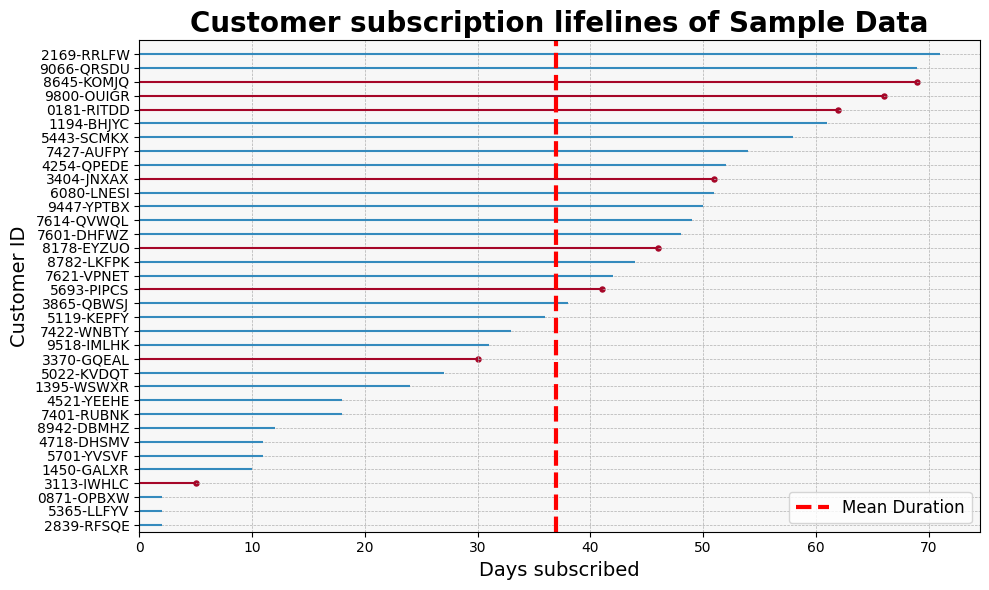

```python
from lifelines.plotting import plot_lifetimes

tenure = train_set_strat[time].sample(35, replace=False)
Churn = train_set_strat[label].sample(35, replace=False)
fig, ax = plt.subplots(figsize=(10, 6))
plot_lifetimes(tenure, Churn, ax=ax)

# Customize the appearance
ax.set_title("Customer subscription lifelines of Sample Data", fontsize=20, fontweight='bold')
ax.set_xlabel("Days subscribed", fontsize=14)
ax.set_ylabel("Customer ID", fontsize=14)
ax.grid(True, which='both', linestyle='--', linewidth=0.5)
ax.axvline(x=tenure.mean(), color='r', linestyle='--', linewidth=3, label='Mean Duration')
ax.legend(loc=4,fontsize=12)

# Customize tick parameters
ax.tick_params(axis='both', which='major', labelsize=10)
ax.tick_params(axis='both', which='minor', labelsize=10)

# Adding a background color
ax.set_facecolor('#f7f7f7')

# Display the plot
plt.tight_layout()
plt.show()
```

A non-parametric statistic that estimates the survival function of time-to-event data. The survival function answers the question: "what is the probability that an event will happen at some time"

$S(t)=P(T>t)$

The Kaplan-Meier Estimator estimates the survival function using time and event data. It is the simplest survival model, providing the probability of the event occurring at time t. The shaded region around the line represents the confidence interval, indicating how confident you can be that the true probability lies within this range.

A 95% confidence interval (CI) means that you are 95% certain it contains the true population value, as it would be estimated from a much larger study.

Also known as

- the product-limit estimator
- the K-M estimator

## How Kaplan-Meier survival curve is constructed?

**Step 1:** Sort the data in ascending order. In cases of ties, place censored data after uncensored data.

**Step 2:** For each t , calculate $d_{i}$ , $n_{i}$ , and

$\large(1-\frac{d_{i}}{n_{i}})$

**Step 3:** For each t , multiply $\large (1-\frac{d_{i}}{n_{i}})$ with

$\large (1-\frac{d_{i-1}}{n_{i-1}}),\,(1-\frac{d_{i-2}}{n_{i-2}}),\,....,(1-\frac{d_{0}}{n_{0}})$

$\Large \hat{S}(t) = \prod_{t_i \le t} \left( 1 - \frac{d_i}{n_i} \right)$

where $t_{i}$ is the time of event, $d_{i}$ is the number of events at, and $n_{i}$ is the number at risk just before.

### Small Example

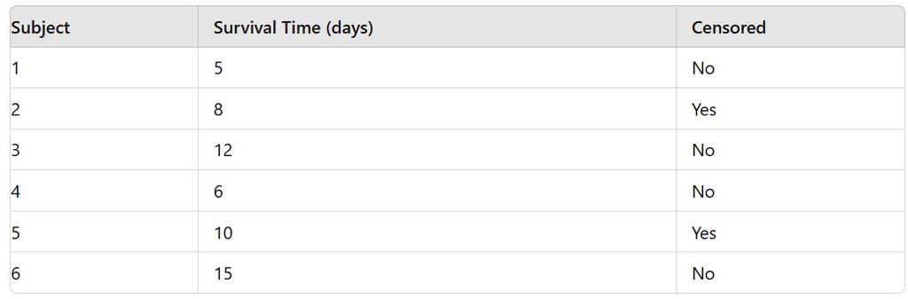

**Sort out Data**

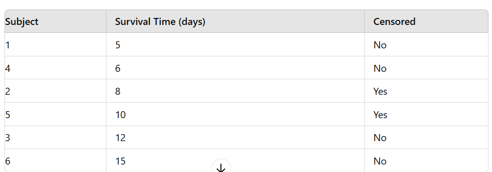

[figure not shown]

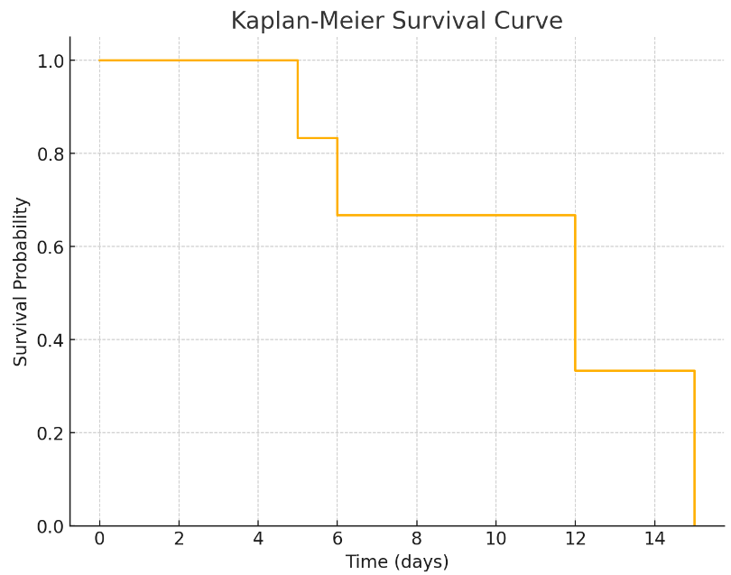

- **Why is the confidence interval useful?**
  - A way to quantify how uncertain we are about each point estimate of survival probabilities
  - A wide confidence interval means we are less certain, often due to small sample size
  - A narrow confidence interval means we are more certain, often due to large sample size

```python
train_set_strat[[time]+[label]]
```

| customerID | tenure | Churn |
| --- | --- | --- |
| 3545-CNWRG | 49.0 | 0 |
| 7673-BQGKU | 69.0 | 0 |
| 2541-YGPKE | 42.0 | 0 |
| 6034-YMTOB | 5.0 | 0 |
| 2984-RGEYA | 69.0 | 0 |
| ... | ... | ... |
| 0218-QNVAS | 71.0 | 0 |
| 2889-FPWRM | 72.0 | 1 |
| 4009-ALQFH | 25.0 | 1 |
| 8024-XNAFQ | 72.0 | 0 |
| 8982-NHAVY | 27.0 | 0 |

5634 rows × 2 columns

Plot survival function point estimates as a continuous line.

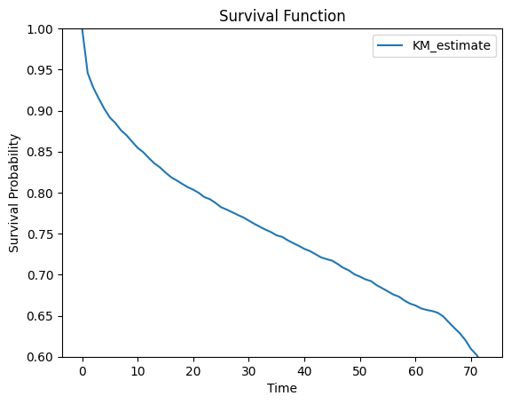

```python
from lifelines import KaplanMeierFitter
from matplotlib import pyplot as plt

T = train_set_strat[time]
E = train_set_strat[label]
kmf = KaplanMeierFitter().fit(T, E, alpha=0.05)
#kmf.plot_survival_function()
kmf.survival_function_.plot()
plt.ylim(0.6, 1);
# Plot the survival function with improved aesthetics
plt.ylim(0.6, 1)
plt.title('Survival Function')
plt.xlabel('Time')
plt.ylabel('Survival Probability')
plt.show()
```

Plot survival function as a stepped line without the confidence interval.

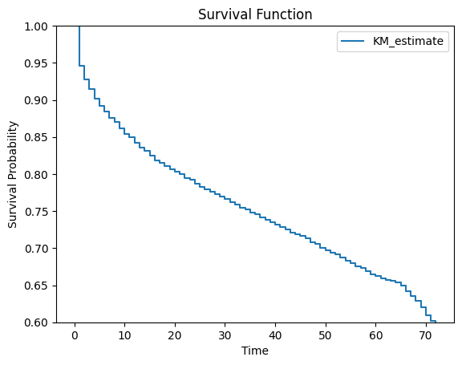

```python
from lifelines import KaplanMeierFitter
from matplotlib import pyplot as plt

T = train_set_strat[time]
E = train_set_strat[label]
kmf = KaplanMeierFitter().fit(T, E, alpha=0.05)
kmf.plot(ci_show=False)
plt.ylim(0.6, 1);
# Plot the survival function with improved aesthetics
plt.ylim(0.6, 1)
plt.title('Survival Function')
plt.xlabel('Time')
plt.ylabel('Survival Probability')
plt.show()
```

## Applying survival analysis to groups

Now we are going to answer this question:

**Is there a difference in time to churn between Male and Female?**

There are different approaches to compare survival analysis between two groups:

**1. Are any point estimates or survival statistics different?**

- Compare two groups' survival probabilities at a specific time
- Compare total proportion of survived subjects across two groups

**2. Are the underlying distributions different?**

- Requires formal hypothesis testing

**3. How much does an attribute affect survival?**

- Requires regression-based modeling frameworks

Fitting a Kaplan-Meier survival function to each group and visualizing their survival curves side by side.

**Benefits:**

- Easy to use and interpret.
- Non-parametric, providing flexibility for various types of survival distributions.
- Serves as an effective illustrative tool to demonstrate differences in survival functions.

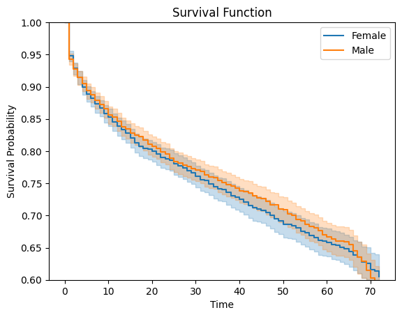

```python
train_set_strat_f = train_set_strat[train_set_strat.gender=='Female']
train_set_strat_m = train_set_strat[train_set_strat.gender=='Male']

ax = plt.subplot(111)
#
T = train_set_strat_f[time]
E = train_set_strat_f[label]
churn_kmf = KaplanMeierFitter()
churn_kmf.fit(T, E, label="Female")
churn_kmf.plot_survival_function(ax=ax)
#
T = train_set_strat_m[time]
E = train_set_strat_m[label]
churn_kmf = KaplanMeierFitter()
churn_kmf.fit(T, E, label="Male")
churn_kmf.plot_survival_function(ax=ax)

plt.ylim(0.6, 1);
# Plot the survival function with improved aesthetics
plt.ylim(0.6, 1)
plt.title('Survival Function')
plt.xlabel('Time')
plt.ylabel('Survival Probability')
plt.show()
```

## Hypothesis Testing

Hypothesis Testing is a statistical method used to make inferences or draw conclusions about a population based on sample data. It involves formulating two competing hypotheses: the null hypothesis (H₀) and the alternative hypothesis (H₁). Here’s an overview:

1. **Null Hypothesis (H₀)**: This is a statement that there is no effect or no difference. It represents the status quo or a baseline assumption that any observed effect is due to random chance. For example, "Female and Male have the same churn rate."
1. **Alternative Hypothesis (H₁)**: This is a statement that there is an effect or a difference. It represents what the researcher aims to prove. For example, "Females have higher churn rate than males."
1. **P-value:** The p-value measures the probability of obtaining test results at least as extreme as the observed data, assuming the null hypothesis is true. A low p-value (typically ≤ 0.05) indicates strong evidence against the null hypothesis, suggesting that it may be rejected in favor of the alternative hypothesis.
1. **Test Statistic:** A value calculated from the sample data that is used to evaluate the plausibility of the null hypothesis. Different tests use different test statistics (e.g., t-statistic, z-statistic).
1. **Significance Level (α)**: A threshold chosen by the researcher (commonly 0.05) that determines whether the p-value is low enough to reject the null hypothesis.
1. **Decision**: Based on the p-value and the significance level, the researcher decides whether to reject or fail to reject the null hypothesis. Rejecting the null hypothesis suggests that there is sufficient evidence to support the alternative hypothesis.

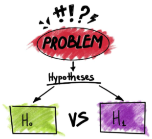

### Log-rank hypothesis testing

- Compares survival probabilities S between groups at each time t

> $H_{0} : S_{a}(t) = S_{b}(t)$

> $H_{1} : S_{a}(t) ≠ S_{b}(t)$
- **P-value**: if $S_{a}(t) = S_{b}(t)$, what's the probability of churn happening?

```python
durations_A = train_set_strat_f[time]
event_observed_A = train_set_strat_f[label]
#
durations_B = train_set_strat_m[time]
event_observed_B = train_set_strat_m[label]
#
from lifelines.statistics import logrank_test
lrt = logrank_test(durations_A, durations_B, event_observed_A, event_observed_B)
```

```python
lrt.print_summary()
```

| t_0 | -1 |
| --- | --- |
| null_distribution | chi squared |
| degrees_of_freedom | 1 |
| test_name | logrank_test |

|  | test_statistic | p | -log2(p) |
| --- | --- | --- | --- |
| 0 | 0.17 | 0.68 | 0.56 |

# `WeibullFitter` Package

## Introducing the Weibull distribution

The Weibull distribution is a continuous probability distribution commonly used in reliability engineering, failure analysis, and survival analysis. Named after Swedish mathematician Waloddi Weibull, it is particularly useful for modeling the time until an event occurs, such as the failure of a component or system.

### Key Properties of the Weibull Distribution

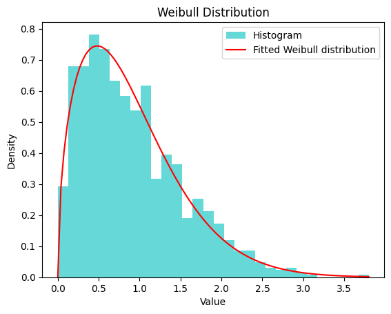

```python
### Example in Python

import numpy as np
import matplotlib.pyplot as plt
import scipy.stats as stats

# Parameters
shape_k = 1.5  # Shape parameter
scale_lambda = 1  # Scale parameter

# Generate data
data = np.random.weibull(shape_k, 1000) * scale_lambda

# Plot histogram
plt.hist(data, bins=30, density=True, alpha=0.6, color='c', label='Histogram')

# Plot PDF
x = np.linspace(0, max(data), 100)
pdf = (shape_k / scale_lambda) * (x / scale_lambda)**(shape_k - 1) * np.exp(-(x / scale_lambda)**shape_k)
plt.plot(x, pdf, 'r-', label='Fitted Weibull distribution')

plt.title('Weibull Distribution')
plt.xlabel('Value')
plt.ylabel('Density')
plt.legend()
plt.show()
```

To convert the Weibull distribution into a survival distribution, you need to focus on the survival function (also known as the reliability function), which is the complement of the cumulative distribution function (CDF). The survival function ( S(x) ) gives the probability that the event of interest (e.g., failure of a component) has not occurred by time ( x ).

### Weibull Survival Function

The survival function $S(x)$ for the Weibull distribution is defined as: $ S(x; \lambda, k) = 1 - F(x; \lambda, k) = e^{-(x/\lambda)^k} $ where:

- $\lambda $ is the scale parameter,
- $ k $ is the shape parameter,
- $ F(x; \lambda, k) $ is the CDF of the Weibull distribution.

### Plotting the Weibull Survival Function in Python

Here's how you can plot the Weibull survival function using Python:

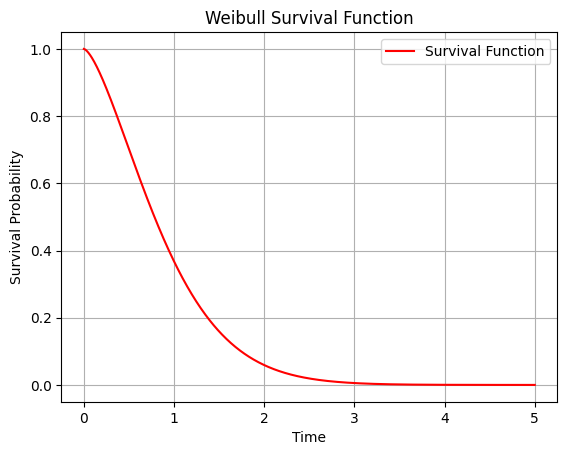

```python
import numpy as np
import matplotlib.pyplot as plt

# Parameters
shape_k = 1.5  # Shape parameter
scale_lambda = 1  # Scale parameter

# Generate data
x = np.linspace(0, 5, 1000)

# Calculate survival function
survival_function = np.exp(-(x / scale_lambda)**shape_k)

# Plot survival function
plt.plot(x, survival_function, 'r-', label='Survival Function')
plt.title('Weibull Survival Function')
plt.xlabel('Time')
plt.ylabel('Survival Probability')
plt.legend()
plt.grid(True)
plt.show()
```

## Survival analysis with Weibull distribution

```python
# Import the WeibullFitter class
from lifelines import WeibullFitter

#Instantiate a WeibullFitter class
wb = WeibullFitter()
```

```python
# Call .fit() to fit the estimator to the data
wb.fit(tenure, Churn)
```

```
<lifelines.WeibullFitter:"Weibull_estimate", fitted with 35 total observations, 27 right-censored observations>
```

Access `.survival_function_` , `.lambda_` , `.rho_` , `.summary` , `.predict()`

In the context of the `WeibullFitter` class from the `lifelines` library, these attributes and methods are used to fit and analyze Weibull survival models. Here's a detailed explanation of each:

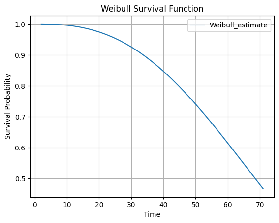

```python
wb.survival_function_.plot()

# Plot survival function
plt.title('Weibull Survival Function')
plt.xlabel('Time')
plt.ylabel('Survival Probability')
plt.legend()
plt.grid(True)
plt.show()
```

```python
print(wb.lambda_, wb.rho_)
```

```
78.65021981037957 2.653534865645372
```

```python
print(wb.predict(50))
```

```
0.7403834568839308
```

### Weibull with Covariates

We already applied Kaplan-Meier estimator to compare groups. See graph below for survival analysis for Male and Female.

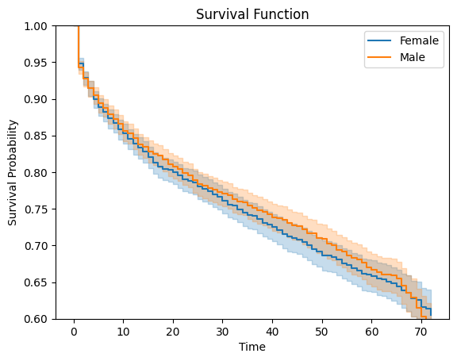

```python
train_set_strat_f = train_set_strat[train_set_strat.gender=='Female']
train_set_strat_m = train_set_strat[train_set_strat.gender=='Male']

ax = plt.subplot(111)
#
T = train_set_strat_f[time]
E = train_set_strat_f[label]
churn_kmf = KaplanMeierFitter()
churn_kmf.fit(T, E, label="Female")
churn_kmf.plot_survival_function(ax=ax)
#
T = train_set_strat_m[time]
E = train_set_strat_m[label]
churn_kmf = KaplanMeierFitter()
churn_kmf.fit(T, E, label="Male")
churn_kmf.plot_survival_function(ax=ax)

plt.ylim(0.6, 1);
# Plot the survival function with improved aesthetics
plt.ylim(0.6, 1)
plt.title('Survival Function')
plt.xlabel('Time')
plt.ylabel('Survival Probability')
plt.show()
```

```python
durations_A = train_set_strat_f[time]
event_observed_A = train_set_strat_f[label]
#
durations_B = train_set_strat_m[time]
event_observed_B = train_set_strat_m[label]
#
from lifelines.statistics import logrank_test
lrt = logrank_test(durations_A, durations_B, event_observed_A, event_observed_B)
```

```python
lrt.print_summary()
```

| t_0 | -1 |
| --- | --- |
| null_distribution | chi squared |
| degrees_of_freedom | 1 |
| test_name | logrank_test |

|  | test_statistic | p | -log2(p) |
| --- | --- | --- | --- |
| 0 | 0.17 | 0.68 | 0.56 |

The expression $-\log_2(p)$ represents the negative base-2 logarithm of a probability $p$. This quantity is often used in information theory and related fields to measure the amount of information or entropy associated with a probability $p$.

Now the question is **How can we evaluate whether and how one or more continuous variables influence the survival function?**

### Survival regression

```python
train_set_time_label
```

| customerID | MonthlyCharges | TotalCharges | gender_Female | gender_Male | SeniorCitizen_No | SeniorCitizen_Yes | Partner_No | Partner_Yes | Dependents_No | Dependents_Yes | PhoneService_No | PhoneService_Yes | MultipleLines_No | MultipleLines_No phone service | MultipleLines_Yes | InternetService_DSL | InternetService_Fiber optic | InternetService_No | OnlineSecurity_No | OnlineSecurity_No internet service | OnlineSecurity_Yes | OnlineBackup_No | OnlineBackup_No internet service | OnlineBackup_Yes | DeviceProtection_No | DeviceProtection_No internet service | DeviceProtection_Yes | TechSupport_No | TechSupport_No internet service | … |
| --- | --- | --- | --- | --- | --- | --- | --- | --- | --- | --- | --- | --- | --- | --- | --- | --- | --- | --- | --- | --- | --- | --- | --- | --- | --- | --- | --- | --- | --- | --- |
| 3545-CNWRG | 98.35 | 4889.20 | 1.0 | 0.0 | 1.0 | 0.0 | 0.0 | 1.0 | 0.0 | 1.0 | 0.0 | 1.0 | 0.0 | 0.0 | 1.0 | 0.0 | 1.0 | 0.0 | 1.0 | 0.0 | 0.0 | 0.0 | 0.0 | 1.0 | 1.0 | 0.0 | 0.0 | 1.0 | 0.0 | … |
| 7673-BQGKU | 20.15 | 1337.50 | 1.0 | 0.0 | 1.0 | 0.0 | 0.0 | 1.0 | 0.0 | 1.0 | 0.0 | 1.0 | 1.0 | 0.0 | 0.0 | 0.0 | 0.0 | 1.0 | 0.0 | 1.0 | 0.0 | 0.0 | 1.0 | 0.0 | 0.0 | 1.0 | 0.0 | 0.0 | 1.0 | … |
| 2541-YGPKE | 63.70 | 2763.35 | 0.0 | 1.0 | 1.0 | 0.0 | 0.0 | 1.0 | 0.0 | 1.0 | 0.0 | 1.0 | 1.0 | 0.0 | 0.0 | 1.0 | 0.0 | 0.0 | 0.0 | 0.0 | 1.0 | 1.0 | 0.0 | 0.0 | 1.0 | 0.0 | 0.0 | 0.0 | 0.0 | … |
| 6034-YMTOB | 75.65 | 399.45 | 1.0 | 0.0 | 1.0 | 0.0 | 1.0 | 0.0 | 1.0 | 0.0 | 0.0 | 1.0 | 1.0 | 0.0 | 0.0 | 0.0 | 1.0 | 0.0 | 1.0 | 0.0 | 0.0 | 1.0 | 0.0 | 0.0 | 1.0 | 0.0 | 0.0 | 0.0 | 0.0 | … |
| 2984-RGEYA | 19.75 | 1375.40 | 1.0 | 0.0 | 1.0 | 0.0 | 0.0 | 1.0 | 0.0 | 1.0 | 0.0 | 1.0 | 1.0 | 0.0 | 0.0 | 0.0 | 0.0 | 1.0 | 0.0 | 1.0 | 0.0 | 0.0 | 1.0 | 0.0 | 0.0 | 1.0 | 0.0 | 0.0 | 1.0 | … |
| ... | ... | ... | ... | ... | ... | ... | ... | ... | ... | ... | ... | ... | ... | ... | ... | ... | ... | ... | ... | ... | ... | ... | ... | ... | ... | ... | ... | ... | ... | … |
| 0218-QNVAS | 100.55 | 7113.75 | 0.0 | 1.0 | 1.0 | 0.0 | 0.0 | 1.0 | 0.0 | 1.0 | 0.0 | 1.0 | 0.0 | 0.0 | 1.0 | 0.0 | 1.0 | 0.0 | 1.0 | 0.0 | 0.0 | 0.0 | 0.0 | 1.0 | 1.0 | 0.0 | 0.0 | 1.0 | 0.0 | … |
| 2889-FPWRM | 117.80 | 8684.80 | 0.0 | 1.0 | 1.0 | 0.0 | 0.0 | 1.0 | 1.0 | 0.0 | 0.0 | 1.0 | 0.0 | 0.0 | 1.0 | 0.0 | 1.0 | 0.0 | 0.0 | 0.0 | 1.0 | 0.0 | 0.0 | 1.0 | 0.0 | 0.0 | 1.0 | 0.0 | 0.0 | … |
| 4009-ALQFH | 99.50 | 2369.05 | 1.0 | 0.0 | 1.0 | 0.0 | 1.0 | 0.0 | 1.0 | 0.0 | 0.0 | 1.0 | 1.0 | 0.0 | 0.0 | 0.0 | 1.0 | 0.0 | 1.0 | 0.0 | 0.0 | 0.0 | 0.0 | 1.0 | 0.0 | 0.0 | 1.0 | 1.0 | 0.0 | … |
| 8024-XNAFQ | 107.40 | 7748.75 | 1.0 | 0.0 | 0.0 | 1.0 | 1.0 | 0.0 | 1.0 | 0.0 | 0.0 | 1.0 | 0.0 | 0.0 | 1.0 | 0.0 | 1.0 | 0.0 | 0.0 | 0.0 | 1.0 | 0.0 | 0.0 | 1.0 | 0.0 | 0.0 | 1.0 | 0.0 | 0.0 | … |
| 8982-NHAVY | 100.50 | 2673.45 | 0.0 | 1.0 | 1.0 | 0.0 | 1.0 | 0.0 | 1.0 | 0.0 | 0.0 | 1.0 | 0.0 | 0.0 | 1.0 | 0.0 | 1.0 | 0.0 | 1.0 | 0.0 | 0.0 | 1.0 | 0.0 | 0.0 | 0.0 | 0.0 | 1.0 | 1.0 | 0.0 | … |

5634 rows × 47 columns

```python
from lifelines import WeibullAFTFitter
aft = WeibullAFTFitter()
train_set_time_label['tenure'] = train_set_time_label['tenure'] + 0.0000001
aft.fit(df=train_set_time_label, duration_col="tenure", event_col="Churn")
```

```
<lifelines.WeibullAFTFitter: fitted with 5634 total observations, 4139 right-censored observations>
```

```python
aft.summary
```

| param | covariate | coef | exp(coef) | se(coef) | coef lower 95% | coef upper 95% | exp(coef) lower 95% | exp(coef) upper 95% | cmp to | z | p | -log2(p) |
| --- | --- | --- | --- | --- | --- | --- | --- | --- | --- | --- | --- | --- |
| lambda_ | Contract_Month-to-month | -0.625910 | 0.534774 | 0.068717 | -0.760592 | -0.491228 | 0.467390 | 0.611874 | 0.0 | -9.108573 | 8.347282e-20 | 63.377255 |
|  | Contract_One year | -0.117617 | 0.889036 | 0.074833 | -0.264288 | 0.029054 | 0.767753 | 1.029480 | 0.0 | -1.571719 | 1.160157e-01 | 3.107609 |
|  | Contract_Two year | 0.637203 | 1.891184 | 0.104509 | 0.432370 | 0.842036 | 1.540905 | 2.321087 | 0.0 | 6.097138 | 1.079842e-09 | 29.786532 |
|  | Dependents_No | -0.177750 | 0.837152 | 0.071699 | -0.318277 | -0.037222 | 0.727401 | 0.963463 | 0.0 | -2.479100 | 1.317143e-02 | 6.246445 |
|  | Dependents_Yes | -0.094509 | 0.909820 | 0.072860 | -0.237311 | 0.048293 | 0.788746 | 1.049478 | 0.0 | -1.297138 | 1.945839e-01 | 2.361536 |
|  | DeviceProtection_No | -0.144414 | 0.865529 | 0.044978 | -0.232569 | -0.056259 | 0.792495 | 0.945294 | 0.0 | -3.210794 | 1.323686e-03 | 9.561223 |
|  | DeviceProtection_No internet service | 0.071509 | 1.074128 | 0.064156 | -0.054234 | 0.197252 | 0.947210 | 1.218051 | 0.0 | 1.114610 | 2.650178e-01 | 1.915839 |
|  | DeviceProtection_Yes | -0.148935 | 0.861625 | 0.130892 | -0.405478 | 0.107608 | 0.666658 | 1.113611 | 0.0 | -1.137852 | 2.551824e-01 | 1.970399 |
|  | InternetService_DSL | 0.239567 | 1.270699 | 0.154473 | -0.063193 | 0.542328 | 0.938762 | 1.720006 | 0.0 | 1.550872 | 1.209323e-01 | 3.047728 |
|  | InternetService_Fiber optic | -0.497227 | 0.608215 | 0.295886 | -1.077154 | 0.082699 | 0.340563 | 1.086215 | 0.0 | -1.680467 | 9.286652e-02 | 3.428698 |
|  | InternetService_No | 0.071509 | 1.074128 | 0.064156 | -0.054234 | 0.197252 | 0.947210 | 1.218051 | 0.0 | 1.114610 | 2.650178e-01 | 1.915839 |
|  | MonthlyCharges | -0.000004 | 0.999996 | 0.017860 | -0.035010 | 0.035001 | 0.965596 | 1.035621 | 0.0 | -0.000231 | 9.998156e-01 | 0.000266 |
|  | MultipleLines_No | -0.078587 | 0.924422 | 0.023857 | -0.125346 | -0.031827 | 0.882192 | 0.968674 | 0.0 | -3.294037 | 9.875951e-04 | 9.983793 |
|  | MultipleLines_No phone service | -0.161648 | 0.850740 | 0.028529 | -0.217565 | -0.105732 | 0.804475 | 0.899666 | 0.0 | -5.666011 | 1.461602e-08 | 26.027874 |
|  | MultipleLines_Yes | -0.096340 | 0.908155 | 0.104498 | -0.301152 | 0.108472 | 0.739965 | 1.114574 | 0.0 | -0.921929 | 3.565654e-01 | 1.487762 |
|  | OnlineBackup_No | -0.165493 | 0.847476 | 0.044559 | -0.252828 | -0.078159 | 0.776602 | 0.924818 | 0.0 | -3.714003 | 2.040063e-04 | 12.259099 |
|  | OnlineBackup_No internet service | 0.071509 | 1.074128 | 0.064156 | -0.054234 | 0.197252 | 0.947210 | 1.218051 | 0.0 | 1.114610 | 2.650178e-01 | 1.915839 |
|  | OnlineBackup_Yes | -0.125277 | 0.882253 | 0.130599 | -0.381247 | 0.130693 | 0.683009 | 1.139618 | 0.0 | -0.959247 | 3.374346e-01 | 1.567320 |
|  | OnlineSecurity_No | -0.245415 | 0.782380 | 0.051645 | -0.346637 | -0.144193 | 0.707062 | 0.865720 | 0.0 | -4.751984 | 2.014307e-06 | 18.921285 |
|  | OnlineSecurity_No internet service | 0.071509 | 1.074128 | 0.064156 | -0.054234 | 0.197252 | 0.947210 | 1.218051 | 0.0 | 1.114610 | 2.650178e-01 | 1.915839 |
|  | OnlineSecurity_Yes | -0.037410 | 0.963282 | 0.137672 | -0.307242 | 0.232423 | 0.735473 | 1.261653 | 0.0 | -0.271729 | 7.858301e-01 | 0.347711 |
|  | PaperlessBilling_No | -0.053089 | 0.948295 | 0.062459 | -0.175507 | 0.069329 | 0.839031 | 1.071788 | 0.0 | -0.849983 | 3.953346e-01 | 1.338854 |
|  | PaperlessBilling_Yes | -0.181115 | 0.834339 | 0.061262 | -0.301187 | -0.061043 | 0.739940 | 0.940782 | 0.0 | -2.956395 | 3.112585e-03 | 8.327671 |
|  | Partner_No | -0.173280 | 0.840902 | 0.060440 | -0.291741 | -0.054819 | 0.746962 | 0.946657 | 0.0 | -2.866952 | 4.144456e-03 | 7.914602 |
|  | Partner_Yes | -0.053971 | 0.947460 | 0.059192 | -0.169986 | 0.062044 | 0.843677 | 1.064009 | 0.0 | -0.911785 | 3.618819e-01 | 1.466409 |
|  | PaymentMethod_Bank transfer (automatic) | 0.086271 | 1.090102 | 0.056765 | -0.024986 | 0.197528 | 0.975323 | 1.218387 | 0.0 | 1.519795 | 1.285624e-01 | 2.959459 |
|  | PaymentMethod_Credit card (automatic) | 0.093706 | 1.098237 | 0.057591 | -0.019170 | 0.206582 | 0.981012 | 1.229469 | 0.0 | 1.627097 | 1.037164e-01 | 3.269284 |
|  | PaymentMethod_Electronic check | -0.192595 | 0.824816 | 0.047560 | -0.285811 | -0.099379 | 0.751404 | 0.905399 | 0.0 | -4.049516 | 5.132368e-05 | 14.250016 |
|  | PaymentMethod_Mailed check | -0.250926 | 0.778080 | 0.054606 | -0.357953 | -0.143900 | 0.699106 | 0.865974 | 0.0 | -4.595186 | 4.323638e-06 | 17.819323 |
|  | PhoneService_No | -0.161648 | 0.850740 | 0.028529 | -0.217565 | -0.105732 | 0.804475 | 0.899666 | 0.0 | -5.666011 | 1.461602e-08 | 26.027874 |
|  | PhoneService_Yes | -0.511905 | 0.599353 | 0.336254 | -1.170950 | 0.147141 | 0.310072 | 1.158517 | 0.0 | -1.522376 | 1.279149e-01 | 2.966743 |
|  | SeniorCitizen_No | -0.206465 | 0.813455 | 0.104921 | -0.412107 | -0.000823 | 0.662254 | 0.999178 | 0.0 | -1.967805 | 4.909043e-02 | 4.348414 |
|  | SeniorCitizen_Yes | -0.211985 | 0.808977 | 0.105803 | -0.419356 | -0.004614 | 0.657470 | 0.995397 | 0.0 | -2.003570 | 4.511610e-02 | 4.470214 |
|  | StreamingMovies_No | -0.068278 | 0.934000 | 0.022077 | -0.111548 | -0.025009 | 0.894449 | 0.975301 | 0.0 | -3.092792 | 1.982832e-03 | 8.978222 |
|  | StreamingMovies_No internet service | 0.071509 | 1.074128 | 0.064156 | -0.054234 | 0.197252 | 0.947210 | 1.218051 | 0.0 | 1.114610 | 2.650178e-01 | 1.915839 |
|  | StreamingMovies_Yes | -0.221827 | 0.801054 | 0.172112 | -0.559160 | 0.115506 | 0.571689 | 1.122441 | 0.0 | -1.288853 | 1.974491e-01 | 2.340447 |
|  | StreamingTV_No | -0.045958 | 0.955082 | 0.021924 | -0.088928 | -0.002988 | 0.914911 | 0.997017 | 0.0 | -2.096251 | 3.605990e-02 | 4.793461 |
|  | StreamingTV_No internet service | 0.071509 | 1.074128 | 0.064156 | -0.054234 | 0.197252 | 0.947210 | 1.218051 | 0.0 | 1.114610 | 2.650178e-01 | 1.915839 |
|  | StreamingTV_Yes | -0.245891 | 0.782008 | 0.173192 | -0.585340 | 0.093558 | 0.556916 | 1.098075 | 0.0 | -1.419762 | 1.556770e-01 | 2.683373 |
|  | TechSupport_No | -0.214250 | 0.807146 | 0.050140 | -0.312523 | -0.115978 | 0.731599 | 0.890495 | 0.0 | -4.273035 | 1.928304e-05 | 15.662308 |
|  | TechSupport_No internet service | 0.071509 | 1.074128 | 0.064156 | -0.054234 | 0.197252 | 0.947210 | 1.218051 | 0.0 | 1.114610 | 2.650178e-01 | 1.915839 |
|  | TechSupport_Yes | -0.074763 | 0.927963 | 0.137096 | -0.343466 | 0.193940 | 0.709307 | 1.214023 | 0.0 | -0.545335 | 5.855233e-01 | 0.772202 |
|  | TotalCharges | 0.000717 | 1.000717 | 0.000020 | 0.000678 | 0.000755 | 1.000679 | 1.000756 | 0.0 | 36.507606 | 8.399247e-292 | 966.932744 |
|  | gender_Female | -0.114614 | 0.891711 | 0.058029 | -0.228348 | -0.000879 | 0.795847 | 0.999121 | 0.0 | -1.975113 | 4.825527e-02 | 4.373170 |
|  | gender_Male | -0.112292 | 0.893783 | 0.059452 | -0.228815 | 0.004231 | 0.795475 | 1.004240 | 0.0 | -1.888792 | 5.891966e-02 | 4.085107 |
|  | Intercept | 5.323952 | 205.193302 | 0.027924 | 5.269222 | 5.378683 | 194.264759 | 216.736641 | 0.0 | 190.657013 | 0.000000e+00 | inf |
| rho_ | Intercept | 0.353859 | 1.424554 | 0.022236 | 0.310277 | 0.397441 | 1.363803 | 1.488011 | 0.0 | 15.913804 | 5.082928e-57 | 187.004242 |

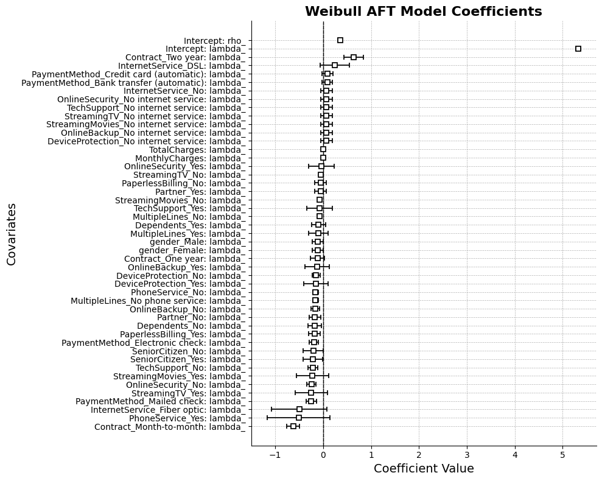

```python
fig, ax = plt.subplots(figsize=(10, 8))  # Set the figure size

# Extract and modify the index
new_index = [(col[0].replace("lambda_", "").replace("Intercept", "").strip(), col[1]) for col in aft.summary.index]
aft.summary.index = pd.MultiIndex.from_tuples(new_index)
aft.plot(ax=ax)

# Beautify the plot
ax.set_title("Weibull AFT Model Coefficients", fontsize=16, fontweight='bold')
ax.set_xlabel("Coefficient Value", fontsize=14)
ax.set_ylabel("Covariates", fontsize=14)
ax.grid(True, linestyle='--', linewidth=0.5)  # Add a grid with custom style
ax.axvline(x=0, color='k', linestyle='--', linewidth=1)  # Add a vertical line at x=0
ax.spines['top'].set_visible(False)  # Hide the top spine
ax.spines['right'].set_visible(False)  # Hide the right spine

# Customize tick parameters
ax.tick_params(axis='x', which='both', bottom=True, top=False, labelbottom=True)
ax.tick_params(axis='y', which='both', left=True, right=False, labelleft=True)

plt.tight_layout()  # Adjust subplots to fit into figure area.

# Show the plot
plt.show()
```

The `plot_partial_effects_on_outcome()` method in the `WeibullAFTFitter` class from the `lifelines` package is used to visualize the impact of specific covariate values on the survival function. This method helps in understanding how changes in covariates affect the predicted survival probability over time.

1. **`covariates`**:
   - This parameter specifies which covariates you want to analyze. It takes a list of strings where each string is the name of a covariate.
   - Example: `covariates=['x1', 'x2']`
2. **`values`**:
   - This parameter specifies the values of the covariates you want to plot. It can take different forms depending on your needs:
     - A list of dictionaries where each dictionary specifies a set of covariate values.
     - A DataFrame where each row represents a set of covariate values.
   - Example: `values=[{'x1': 1, 'x2': 3}, {'x1': 2, 'x2': 5}]`

**Baseline Survival Curve**

- The baseline survival curve is the survival function when all covariates are at their reference levels (often zero or the mean value depending on the data standardization/normalization).
- In the context of `plot_partial_effects_on_outcome()`, the baseline survival curve serves as a reference to compare how the survival probabilities change when covariate values are modified.

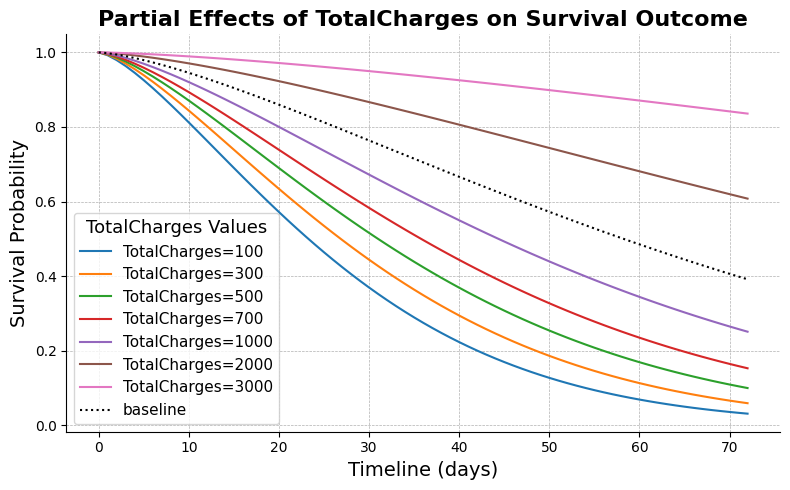

```python
# Plot partial effects on outcome
fig, ax = plt.subplots(figsize=(8, 5))  # Set the figure size
aft.plot_partial_effects_on_outcome(covariates=['TotalCharges'], values=[100, 300, 500, 700, 1000, 2000, 3000], ax=ax)

# Beautify the plot
ax.set_title("Partial Effects of TotalCharges on Survival Outcome", fontsize=16, fontweight='bold')
ax.set_xlabel("Timeline (days)", fontsize=14)
ax.set_ylabel("Survival Probability", fontsize=14)
ax.grid(True, linestyle='--', linewidth=0.5)  # Add a grid with custom style
ax.spines['top'].set_visible(False)  # Hide the top spine
ax.spines['right'].set_visible(False)  # Hide the right spine

# Customize tick parameters
ax.tick_params(axis='x', which='both', bottom=True, top=False, labelbottom=True)
ax.tick_params(axis='y', which='both', left=True, right=False, labelleft=True)

plt.legend(title="TotalCharges Values", title_fontsize='13', fontsize='11')  # Customize the legend

plt.tight_layout()  # Adjust subplots to fit into figure area

# Show the plot
plt.show()
```

```python
train_set_time_label['Contract_Month-to-month']
```

```
customerID
3545-CNWRG    1.0
7673-BQGKU    0.0
2541-YGPKE    0.0
6034-YMTOB    1.0
2984-RGEYA    0.0
             ...
0218-QNVAS    0.0
2889-FPWRM    0.0
4009-ALQFH    1.0
8024-XNAFQ    0.0
8982-NHAVY    0.0
Name: Contract_Month-to-month, Length: 5634, dtype: float64
```

[figure not shown]

```python
# Plot partial effects on outcome
fig, ax = plt.subplots(figsize=(8, 5))  # Set the figure size
aft.plot_partial_effects_on_outcome(covariates=['Contract_Two year'], values=[0, 1], ax=ax)

# Beautify the plot
ax.set_title("Partial Effects of Contract_Month-to-month on Survival Outcome", fontsize=16, fontweight='bold')
ax.set_xlabel("Timeline (days)", fontsize=14)
ax.set_ylabel("Survival Probability", fontsize=14)
ax.grid(True, linestyle='--', linewidth=0.5)  # Add a grid with custom style
ax.spines['top'].set_visible(False)  # Hide the top spine
ax.spines['right'].set_visible(False)  # Hide the right spine

# Customize tick parameters
ax.tick_params(axis='x', which='both', bottom=True, top=False, labelbottom=True)
ax.tick_params(axis='y', which='both', left=True, right=False, labelleft=True)

plt.legend(title="Contract_Two year", title_fontsize='13', fontsize='11')  # Customize the legend

plt.tight_layout()  # Adjust subplots to fit into figure area

# Show the plot
plt.show()
```

## Predict Survival Time

- `.predict_survival_function()`: Predict survival functions of individuals based on covariate values.
  - Arguments: `X` ( `np` array or DataFrame): covariates. If a DataFrame, columns can be in any order.
  - **conditional_after** (Optional): A time point after which the survival probabilities are conditioned. This means the survival probabilities are recalculated given that the individual has already survived up to conditional_after time units.
- `.predict_median()`: `X` ( np array or DataFrame): covariates. If a DataFrame, columns can be in any order. Predict median survival durations of individuals based on covariate values.
  - `df` ( `np` array or DataFrame): covariates. If a DataFrame, columns can be in any order.

```python
# Apply the transformations
df_processed = preprocessor.fit_transform(test_set_strat)

# Get feature names
numerical_feature_names = numerical_features
categorical_feature_names = preprocessor.named_transformers_['cat']['onehot'].get_feature_names_out(categorical_features)

# Combine feature names
feature_names = np.concatenate([numerical_feature_names, categorical_feature_names])

# Convert the result back to a DataFrame for better readability
df_processed = pd.DataFrame(df_processed, columns=feature_names, index=test_set_strat.index)

df_processed
```

| customerID | MonthlyCharges | TotalCharges | gender_Female | gender_Male | SeniorCitizen_No | SeniorCitizen_Yes | Partner_No | Partner_Yes | Dependents_No | Dependents_Yes | PhoneService_No | PhoneService_Yes | MultipleLines_No | MultipleLines_No phone service | MultipleLines_Yes | InternetService_DSL | InternetService_Fiber optic | InternetService_No | OnlineSecurity_No | OnlineSecurity_No internet service | OnlineSecurity_Yes | OnlineBackup_No | OnlineBackup_No internet service | OnlineBackup_Yes | DeviceProtection_No | DeviceProtection_No internet service | DeviceProtection_Yes | TechSupport_No | TechSupport_No internet service | … |
| --- | --- | --- | --- | --- | --- | --- | --- | --- | --- | --- | --- | --- | --- | --- | --- | --- | --- | --- | --- | --- | --- | --- | --- | --- | --- | --- | --- | --- | --- | --- |
| 0023-UYUPN | 25.20 | 1306.30 | 1.0 | 0.0 | 0.0 | 1.0 | 0.0 | 1.0 | 1.0 | 0.0 | 0.0 | 1.0 | 0.0 | 0.0 | 1.0 | 0.0 | 0.0 | 1.0 | 0.0 | 1.0 | 0.0 | 0.0 | 1.0 | 0.0 | 0.0 | 1.0 | 0.0 | 0.0 | 1.0 | … |
| 7610-TVOPG | 26.35 | 378.60 | 0.0 | 1.0 | 1.0 | 0.0 | 1.0 | 0.0 | 1.0 | 0.0 | 0.0 | 1.0 | 0.0 | 0.0 | 1.0 | 0.0 | 0.0 | 1.0 | 0.0 | 1.0 | 0.0 | 0.0 | 1.0 | 0.0 | 0.0 | 1.0 | 0.0 | 0.0 | 1.0 | … |
| 8050-DVOJX | 81.35 | 4060.90 | 0.0 | 1.0 | 0.0 | 1.0 | 1.0 | 0.0 | 1.0 | 0.0 | 0.0 | 1.0 | 0.0 | 0.0 | 1.0 | 1.0 | 0.0 | 0.0 | 0.0 | 0.0 | 1.0 | 0.0 | 0.0 | 1.0 | 0.0 | 0.0 | 1.0 | 0.0 | 0.0 | … |
| 8189-DUKMV | 20.50 | 79.05 | 1.0 | 0.0 | 1.0 | 0.0 | 0.0 | 1.0 | 1.0 | 0.0 | 0.0 | 1.0 | 1.0 | 0.0 | 0.0 | 0.0 | 0.0 | 1.0 | 0.0 | 1.0 | 0.0 | 0.0 | 1.0 | 0.0 | 0.0 | 1.0 | 0.0 | 0.0 | 1.0 | … |
| 2911-WDXMV | 80.55 | 1406.65 | 0.0 | 1.0 | 1.0 | 0.0 | 1.0 | 0.0 | 0.0 | 1.0 | 0.0 | 1.0 | 0.0 | 0.0 | 1.0 | 0.0 | 1.0 | 0.0 | 1.0 | 0.0 | 0.0 | 1.0 | 0.0 | 0.0 | 0.0 | 0.0 | 1.0 | 1.0 | 0.0 | … |
| ... | ... | ... | ... | ... | ... | ... | ... | ... | ... | ... | ... | ... | ... | ... | ... | ... | ... | ... | ... | ... | ... | ... | ... | ... | ... | ... | ... | ... | ... | … |
| 8777-PVYGU | 64.30 | 3410.60 | 1.0 | 0.0 | 1.0 | 0.0 | 0.0 | 1.0 | 1.0 | 0.0 | 0.0 | 1.0 | 1.0 | 0.0 | 0.0 | 1.0 | 0.0 | 0.0 | 0.0 | 0.0 | 1.0 | 1.0 | 0.0 | 0.0 | 0.0 | 0.0 | 1.0 | 1.0 | 0.0 | … |
| 6519-CFDBX | 45.40 | 80.95 | 1.0 | 0.0 | 1.0 | 0.0 | 1.0 | 0.0 | 1.0 | 0.0 | 0.0 | 1.0 | 1.0 | 0.0 | 0.0 | 1.0 | 0.0 | 0.0 | 1.0 | 0.0 | 0.0 | 1.0 | 0.0 | 0.0 | 1.0 | 0.0 | 0.0 | 1.0 | 0.0 | … |
| 6384-VMJHP | 73.00 | 5265.20 | 1.0 | 0.0 | 1.0 | 0.0 | 1.0 | 0.0 | 1.0 | 0.0 | 0.0 | 1.0 | 1.0 | 0.0 | 0.0 | 1.0 | 0.0 | 0.0 | 0.0 | 0.0 | 1.0 | 0.0 | 0.0 | 1.0 | 0.0 | 0.0 | 1.0 | 0.0 | 0.0 | … |
| 3441-CGZJH | 60.40 | 2640.55 | 1.0 | 0.0 | 1.0 | 0.0 | 0.0 | 1.0 | 0.0 | 1.0 | 1.0 | 0.0 | 0.0 | 1.0 | 0.0 | 1.0 | 0.0 | 0.0 | 0.0 | 0.0 | 1.0 | 1.0 | 0.0 | 0.0 | 0.0 | 0.0 | 1.0 | 0.0 | 0.0 | … |
| 5274-XHAKY | 94.30 | 3893.60 | 1.0 | 0.0 | 1.0 | 0.0 | 0.0 | 1.0 | 0.0 | 1.0 | 0.0 | 1.0 | 0.0 | 0.0 | 1.0 | 0.0 | 1.0 | 0.0 | 0.0 | 0.0 | 1.0 | 0.0 | 0.0 | 1.0 | 1.0 | 0.0 | 0.0 | 1.0 | 0.0 | … |

1409 rows × 45 columns

```python
test_set_strat[label].replace({'Yes': 1, 'No': 0}, inplace=True)
test_set_strat
```

| customerID | gender | SeniorCitizen | Partner | Dependents | tenure | PhoneService | MultipleLines | InternetService | OnlineSecurity | OnlineBackup | DeviceProtection | TechSupport | StreamingTV | StreamingMovies | Contract | PaperlessBilling | PaymentMethod | MonthlyCharges | TotalCharges | Churn |
| --- | --- | --- | --- | --- | --- | --- | --- | --- | --- | --- | --- | --- | --- | --- | --- | --- | --- | --- | --- | --- |
| 0023-UYUPN | Female | Yes | Yes | No | 50.0 | Yes | Yes | No | No internet service | No internet service | No internet service | No internet service | No internet service | No internet service | One year | No | Electronic check | 25.20 | 1306.30 | 0 |
| 7610-TVOPG | Male | No | No | No | 15.0 | Yes | Yes | No | No internet service | No internet service | No internet service | No internet service | No internet service | No internet service | Month-to-month | Yes | Electronic check | 26.35 | 378.60 | 0 |
| 8050-DVOJX | Male | Yes | No | No | 49.0 | Yes | Yes | DSL | Yes | Yes | Yes | Yes | No | Yes | Two year | No | Credit card (automatic) | 81.35 | 4060.90 | 0 |
| 8189-DUKMV | Female | No | Yes | No | 4.0 | Yes | No | No | No internet service | No internet service | No internet service | No internet service | No internet service | No internet service | One year | No | Bank transfer (automatic) | 20.50 | 79.05 | 0 |
| 2911-WDXMV | Male | No | No | Yes | 18.0 | Yes | Yes | Fiber optic | No | No | Yes | No | No | No | Month-to-month | Yes | Credit card (automatic) | 80.55 | 1406.65 | 0 |
| ... | ... | ... | ... | ... | ... | ... | ... | ... | ... | ... | ... | ... | ... | ... | ... | ... | ... | ... | ... | ... |
| 8777-PVYGU | Female | No | Yes | No | 52.0 | Yes | No | DSL | Yes | No | Yes | No | Yes | No | One year | Yes | Mailed check | 64.30 | 3410.60 | 0 |
| 6519-CFDBX | Female | No | No | No | 2.0 | Yes | No | DSL | No | No | No | No | No | No | Month-to-month | Yes | Electronic check | 45.40 | 80.95 | 0 |
| 6384-VMJHP | Female | No | No | No | 72.0 | Yes | No | DSL | Yes | Yes | Yes | Yes | No | Yes | Two year | Yes | Credit card (automatic) | 73.00 | 5265.20 | 0 |
| 3441-CGZJH | Female | No | Yes | Yes | 43.0 | No | No phone service | DSL | Yes | No | Yes | Yes | Yes | Yes | One year | Yes | Credit card (automatic) | 60.40 | 2640.55 | 0 |
| 5274-XHAKY | Female | No | Yes | Yes | 41.0 | Yes | Yes | Fiber optic | Yes | Yes | No | No | Yes | No | Month-to-month | Yes | Bank transfer (automatic) | 94.30 | 3893.60 | 0 |

1409 rows × 20 columns

```python
df_processed
```

| customerID | MonthlyCharges | TotalCharges | gender_Female | gender_Male | SeniorCitizen_No | SeniorCitizen_Yes | Partner_No | Partner_Yes | Dependents_No | Dependents_Yes | PhoneService_No | PhoneService_Yes | MultipleLines_No | MultipleLines_No phone service | MultipleLines_Yes | InternetService_DSL | InternetService_Fiber optic | InternetService_No | OnlineSecurity_No | OnlineSecurity_No internet service | OnlineSecurity_Yes | OnlineBackup_No | OnlineBackup_No internet service | OnlineBackup_Yes | DeviceProtection_No | DeviceProtection_No internet service | DeviceProtection_Yes | TechSupport_No | TechSupport_No internet service | … |
| --- | --- | --- | --- | --- | --- | --- | --- | --- | --- | --- | --- | --- | --- | --- | --- | --- | --- | --- | --- | --- | --- | --- | --- | --- | --- | --- | --- | --- | --- | --- |
| 0023-UYUPN | 25.20 | 1306.30 | 1.0 | 0.0 | 0.0 | 1.0 | 0.0 | 1.0 | 1.0 | 0.0 | 0.0 | 1.0 | 0.0 | 0.0 | 1.0 | 0.0 | 0.0 | 1.0 | 0.0 | 1.0 | 0.0 | 0.0 | 1.0 | 0.0 | 0.0 | 1.0 | 0.0 | 0.0 | 1.0 | … |
| 7610-TVOPG | 26.35 | 378.60 | 0.0 | 1.0 | 1.0 | 0.0 | 1.0 | 0.0 | 1.0 | 0.0 | 0.0 | 1.0 | 0.0 | 0.0 | 1.0 | 0.0 | 0.0 | 1.0 | 0.0 | 1.0 | 0.0 | 0.0 | 1.0 | 0.0 | 0.0 | 1.0 | 0.0 | 0.0 | 1.0 | … |
| 8050-DVOJX | 81.35 | 4060.90 | 0.0 | 1.0 | 0.0 | 1.0 | 1.0 | 0.0 | 1.0 | 0.0 | 0.0 | 1.0 | 0.0 | 0.0 | 1.0 | 1.0 | 0.0 | 0.0 | 0.0 | 0.0 | 1.0 | 0.0 | 0.0 | 1.0 | 0.0 | 0.0 | 1.0 | 0.0 | 0.0 | … |
| 8189-DUKMV | 20.50 | 79.05 | 1.0 | 0.0 | 1.0 | 0.0 | 0.0 | 1.0 | 1.0 | 0.0 | 0.0 | 1.0 | 1.0 | 0.0 | 0.0 | 0.0 | 0.0 | 1.0 | 0.0 | 1.0 | 0.0 | 0.0 | 1.0 | 0.0 | 0.0 | 1.0 | 0.0 | 0.0 | 1.0 | … |
| 2911-WDXMV | 80.55 | 1406.65 | 0.0 | 1.0 | 1.0 | 0.0 | 1.0 | 0.0 | 0.0 | 1.0 | 0.0 | 1.0 | 0.0 | 0.0 | 1.0 | 0.0 | 1.0 | 0.0 | 1.0 | 0.0 | 0.0 | 1.0 | 0.0 | 0.0 | 0.0 | 0.0 | 1.0 | 1.0 | 0.0 | … |
| ... | ... | ... | ... | ... | ... | ... | ... | ... | ... | ... | ... | ... | ... | ... | ... | ... | ... | ... | ... | ... | ... | ... | ... | ... | ... | ... | ... | ... | ... | … |
| 8777-PVYGU | 64.30 | 3410.60 | 1.0 | 0.0 | 1.0 | 0.0 | 0.0 | 1.0 | 1.0 | 0.0 | 0.0 | 1.0 | 1.0 | 0.0 | 0.0 | 1.0 | 0.0 | 0.0 | 0.0 | 0.0 | 1.0 | 1.0 | 0.0 | 0.0 | 0.0 | 0.0 | 1.0 | 1.0 | 0.0 | … |
| 6519-CFDBX | 45.40 | 80.95 | 1.0 | 0.0 | 1.0 | 0.0 | 1.0 | 0.0 | 1.0 | 0.0 | 0.0 | 1.0 | 1.0 | 0.0 | 0.0 | 1.0 | 0.0 | 0.0 | 1.0 | 0.0 | 0.0 | 1.0 | 0.0 | 0.0 | 1.0 | 0.0 | 0.0 | 1.0 | 0.0 | … |
| 6384-VMJHP | 73.00 | 5265.20 | 1.0 | 0.0 | 1.0 | 0.0 | 1.0 | 0.0 | 1.0 | 0.0 | 0.0 | 1.0 | 1.0 | 0.0 | 0.0 | 1.0 | 0.0 | 0.0 | 0.0 | 0.0 | 1.0 | 0.0 | 0.0 | 1.0 | 0.0 | 0.0 | 1.0 | 0.0 | 0.0 | … |
| 3441-CGZJH | 60.40 | 2640.55 | 1.0 | 0.0 | 1.0 | 0.0 | 0.0 | 1.0 | 0.0 | 1.0 | 1.0 | 0.0 | 0.0 | 1.0 | 0.0 | 1.0 | 0.0 | 0.0 | 0.0 | 0.0 | 1.0 | 1.0 | 0.0 | 0.0 | 0.0 | 0.0 | 1.0 | 0.0 | 0.0 | … |
| 5274-XHAKY | 94.30 | 3893.60 | 1.0 | 0.0 | 1.0 | 0.0 | 0.0 | 1.0 | 0.0 | 1.0 | 0.0 | 1.0 | 0.0 | 0.0 | 1.0 | 0.0 | 1.0 | 0.0 | 0.0 | 0.0 | 1.0 | 0.0 | 0.0 | 1.0 | 1.0 | 0.0 | 0.0 | 1.0 | 0.0 | … |

1409 rows × 45 columns

```python
test_set_strat_time_label = pd.merge(df_processed, test_set_strat[['tenure', 'Churn']],
                                     left_index=True, right_index=True, how='left')
test_set_strat_time_label.head()
```

| customerID | MonthlyCharges | TotalCharges | gender_Female | gender_Male | SeniorCitizen_No | SeniorCitizen_Yes | Partner_No | Partner_Yes | Dependents_No | Dependents_Yes | PhoneService_No | PhoneService_Yes | MultipleLines_No | MultipleLines_No phone service | MultipleLines_Yes | InternetService_DSL | InternetService_Fiber optic | InternetService_No | OnlineSecurity_No | OnlineSecurity_No internet service | OnlineSecurity_Yes | OnlineBackup_No | OnlineBackup_No internet service | OnlineBackup_Yes | DeviceProtection_No | DeviceProtection_No internet service | DeviceProtection_Yes | TechSupport_No | TechSupport_No internet service | … |
| --- | --- | --- | --- | --- | --- | --- | --- | --- | --- | --- | --- | --- | --- | --- | --- | --- | --- | --- | --- | --- | --- | --- | --- | --- | --- | --- | --- | --- | --- | --- |
| 0023-UYUPN | 25.20 | 1306.30 | 1.0 | 0.0 | 0.0 | 1.0 | 0.0 | 1.0 | 1.0 | 0.0 | 0.0 | 1.0 | 0.0 | 0.0 | 1.0 | 0.0 | 0.0 | 1.0 | 0.0 | 1.0 | 0.0 | 0.0 | 1.0 | 0.0 | 0.0 | 1.0 | 0.0 | 0.0 | 1.0 | … |
| 7610-TVOPG | 26.35 | 378.60 | 0.0 | 1.0 | 1.0 | 0.0 | 1.0 | 0.0 | 1.0 | 0.0 | 0.0 | 1.0 | 0.0 | 0.0 | 1.0 | 0.0 | 0.0 | 1.0 | 0.0 | 1.0 | 0.0 | 0.0 | 1.0 | 0.0 | 0.0 | 1.0 | 0.0 | 0.0 | 1.0 | … |
| 8050-DVOJX | 81.35 | 4060.90 | 0.0 | 1.0 | 0.0 | 1.0 | 1.0 | 0.0 | 1.0 | 0.0 | 0.0 | 1.0 | 0.0 | 0.0 | 1.0 | 1.0 | 0.0 | 0.0 | 0.0 | 0.0 | 1.0 | 0.0 | 0.0 | 1.0 | 0.0 | 0.0 | 1.0 | 0.0 | 0.0 | … |
| 8189-DUKMV | 20.50 | 79.05 | 1.0 | 0.0 | 1.0 | 0.0 | 0.0 | 1.0 | 1.0 | 0.0 | 0.0 | 1.0 | 1.0 | 0.0 | 0.0 | 0.0 | 0.0 | 1.0 | 0.0 | 1.0 | 0.0 | 0.0 | 1.0 | 0.0 | 0.0 | 1.0 | 0.0 | 0.0 | 1.0 | … |
| 2911-WDXMV | 80.55 | 1406.65 | 0.0 | 1.0 | 1.0 | 0.0 | 1.0 | 0.0 | 0.0 | 1.0 | 0.0 | 1.0 | 0.0 | 0.0 | 1.0 | 0.0 | 1.0 | 0.0 | 1.0 | 0.0 | 0.0 | 1.0 | 0.0 | 0.0 | 0.0 | 0.0 | 1.0 | 1.0 | 0.0 | … |

Predict the survival function for individuals, given their covariates. This assumes that the individual just entered the study (that is, we do not condition on how long they have already lived for.

```python
#aft.predict_survival_function(test_set_strat_time_label.iloc[0], conditional_after=10)
customer_1 = aft.predict_survival_function(test_set_strat_time_label.iloc[:2])
customer_1.head()
```

| customerID | 0023-UYUPN | 7610-TVOPG |
| --- | --- | --- |
| 1.000000e-07 | 1.000000 | 1.000000 |
| 1.000000e+00 | 0.999420 | 0.995666 |
| 2.000000e+00 | 0.998443 | 0.988410 |
| 3.000000e+00 | 0.997228 | 0.979442 |
| 4.000000e+00 | 0.995827 | 0.969191 |

```python
aft.predict_median(test_set_strat_time_label)
```

```
0023-UYUPN     144.567957
7610-TVOPG      35.194502
8050-DVOJX    1050.752765
8189-DUKMV      81.133199
2911-WDXMV      16.136747
                 ...
8777-PVYGU     177.297121
6519-CFDBX       9.189431
6384-VMJHP    2238.554347
3441-CGZJH     201.703757
5274-XHAKY     112.877190
Length: 1409, dtype: float64
```

In survival analysis, comparing predicted median survival times directly with actual times can be challenging because the actual times include both censored and uncensored data. Here's how you can handle this situation:

**Filter Uncensored Data:** Only use the uncensored data for calculating the Mean Absolute Error (MAE). For censored data, the exact survival time is unknown, making it inappropriate to include them directly in the MAE calculation.

**Calculate MAE for Uncensored Data:** Compute the MAE between the predicted median survival times and the actual times for the uncensored subset of your test data.

```python
uncensored_tenure_test = test_set_strat_time_label[test_set_strat_time_label.Churn==1]
```

```python
x = uncensored_tenure_test.tenure.values
```

```python
y = aft.predict_median(uncensored_tenure_test).values
```

```python
from sklearn.metrics import mean_absolute_error
mae = mean_absolute_error(x, y)
print(f"Mean Absolute Error: {mae}")
```

```
Mean Absolute Error: 124.89845413868007
```

```python
def CrossPlot (x:list,y:list,title:str,xlabl:str,ylabl:str,loc:int,
               xlimt:list,ylimt:list,axt=None,scale: float=0.8,alpha: float=0.6,
               markersize: float=6,marker: str='ro',fit_ : bool=True,
               markeredgecolor='white', color='black') -> None:
    #
    ax1 = axt or plt.axes()
    x=np.array(x)
    y=np.array(y)
    no_nan=np.where((~np.isnan(x)) & (~np.isnan(y)))[0]
    Mean_x=np.mean(x)
    SD_x=np.sqrt(np.var(x))
    #
    n_x=len(x)
    n_y=len(y)
    Mean_y=np.mean(y)
    SD_y=np.sqrt(np.var(y))
    corr=np.corrcoef(x[no_nan],y[no_nan])
    n_=len(no_nan)

    txt = r'$\rho_{x,y}$=%.2f' + '\n $n$=%.0f \n $\mu_{x}$=%.0f  \n '
    txt += '$\mu_{y}$=%.2f '
    anchored_text = AnchoredText(txt %(corr[1,0], n_x,Mean_x,Mean_y), loc=loc,
                            prop={ 'size': font['size']*scale, 'fontweight': 'bold'})

    ax1.add_artist(anchored_text)
    Lfunc1=np.polyfit(x,y,1)
    vEst=Lfunc1[0]*x+Lfunc1[1]
    try:
        title
    except NameError:
        pass  # do nothing!
    else:
        plt.title(title,fontsize=font['size']*(scale))
#
    try:
        xlabl
    except NameError:
        pass  # do nothing!
    else:
        plt.xlabel(xlabl,fontsize=font['size']*scale)
#
    try:
        ylabl
    except NameError:
        pass  # do nothing!
    else:
        plt.ylabel(ylabl,fontsize=font['size']*scale)

    try:
        xlimt
    except NameError:
        pass  # do nothing!
    else:
        plt.xlim(xlimt)
#
    try:
        ylimt
    except NameError:
        pass  # do nothing!
    else:
        plt.ylim(ylimt)

    plt.plot(x,y,marker,markersize=markersize, alpha=alpha, markeredgecolor=markeredgecolor, color=color)
    if fit_: ax1.plot(x, vEst,'k-',linewidth=2)
    ax1.grid(linewidth='0.1')
    plt.xticks(fontsize=font['size']*scale)
    plt.yticks(fontsize=font['size']*scale)
```

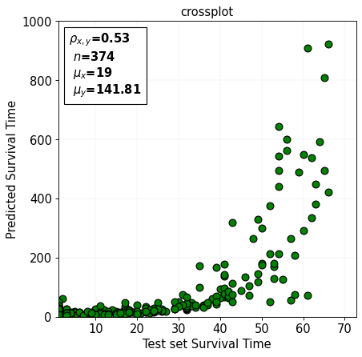

```python
font = {'size'   : 12}
plt.rc('font', **font)
fig, ax1 = plt.subplots(figsize=(6, 6), dpi= 80, facecolor='w', edgecolor='k')

CrossPlot(x,y,title=f'crossplot',
          xlabl='Test set Survival Time',
          ylabl='Predicted Survival Time',
          loc=2,
          xlimt=(np.nanmin(x)-np.nanmin(x)*0.01,np.nanmax(x)+np.nanmax(x)*0.01),
          ylimt=(0, 1000),
          axt=ax1,
          scale=1.1,
          alpha=1,
          fit_=False,
          markersize=8,
          marker='o',
          color='g',
          markeredgecolor='black')


plt.show()
```

# Which model fits the data the best?

When choosing between non-parametric and parametric models for survival analysis, it's important to weigh their respective advantages and limitations. Here’s a detailed comparison:

**Non-parametric Modeling (e.g., Kaplan-Meier Model)**

- **Advantages**:
  - **Distribution-free**: The Kaplan-Meier model does not assume any specific distribution for the survival times, making it flexible and robust.
  - **Describes Data Accurately**: It provides an empirical estimate of the survival function, which can accurately reflect the observed data without imposing any assumptions about the underlying distribution.
- **Disadvantages**:
  - **Not Smooth/Continuous/Differentiable**: The survival function estimated by the Kaplan-Meier model is a step function, which can be less smooth and harder to interpret compared to parametric models. This can make it difficult to derive certain statistical properties and to make predictions for times not directly observed in the data.

**Parametric Modeling (e.g., Weibull Model)**

- **Advantages**:
  - **More Information**: Parametric models can provide more detailed insights and predictions about the survival process. They often allow for the derivation of various statistics (e.g., hazard functions, cumulative hazard functions) that are not directly obtainable from non-parametric models.
  - **Smooth and Continuous**: Parametric models typically provide smooth, continuous, and differentiable estimates of the survival function, which can be more interpretable and useful for further statistical analysis.
- **Disadvantages**:
  - **Model Assumptions**: Parametric models assume that the survival times follow a specific distribution (e.g., Weibull, exponential, log-normal). If the chosen model does not fit the actual data well, this can lead to biased estimates and incorrect conclusions.
  - **Model Selection**: Selecting the correct parametric model requires careful consideration and validation, which can be challenging.

Common parametric survival models

- The `Weibull` model

  ```
  from lifelines import WeibullFitter
  ```

- The `Exponential` model

  ```
  from lifelines import ExponentialFitter
  ```

- The `Log Normal` model

  ```
  from lifelines import LogNormalFitter
  ```

- The `Log Logistic` model

  ```
  from lifelines import LogLogisticFitter
  ```

- The `Gamma` model

  ```
  from lifelines import GeneralizedGammaFitter
  ```

## The Akaike Information Criterion (AIC)

**AIC:** An estimator used to measure the prediction error and relative quality of statistical models for a given dataset.

- **Estimates Information Loss:**
  - The AIC estimates the relative amount of information lost by a given model.
  - It includes a penalty for the number of parameters estimated, discouraging overfitting.
  - The goal is to find a model that loses the least amount of information while being as simple as possible.
- **Model Quality:**
  - A model that loses less information is considered higher quality.
  - Simpler models (with fewer parameters) are preferred, as they are considered higher quality if they achieve a similar level of accuracy.
- **Model Selection:**
  - When comparing a set of candidate models for the data, the model with the lowest AIC value is preferred.

To perform model selection using the Akaike Information Criterion (AIC) with parametric models in the `lifelines` library, you can follow these steps:

**Step 1: Fit Parametric Models in Lifelines**

```
First, you need to fit several parametric survival models using the `lifelines` library. Lifelines provides various parametric models like the Exponential, Weibull, and Log-Normal models.
```

**Step 2: Print and Compare Each Model's `AIC_` Property**

```
After fitting the models, you can access the `AIC_` property of each model to get their AIC values. The AIC is a measure of the relative quality of statistical models for a given dataset. Lower AIC values indicate a better fit.
```

**Step 3: Select the Model with the Lowest AIC Value**

```
The model with the lowest AIC value is considered the preferred model.
```

```python
from lifelines import WeibullFitter,\
ExponentialFitter,LogNormalFitter
```

```python
T = train_set_time_label['tenure']
E = train_set_time_label['Churn']
```

```python
wb = WeibullFitter().fit(T, E)
exp = ExponentialFitter().fit(T, E)
log = LogNormalFitter().fit(T, E)
```

```python
print(f'AIC_ for WeibullFitter: {int(wb.AIC_)}')
print(f'AIC_ for ExponentialFitter: {int(exp.AIC_)}')
print(f'AIC_ for LogNormalFitter: {int(log.AIC_)}')
```

```
AIC_ for WeibullFitter: 16898
AIC_ for ExponentialFitter: 17327
AIC_ for LogNormalFitter: 16804
```

## `find_best_parametric_model()`

`find_best_parametric_model()` is a built-in lifelines function to automate AIC comparisons between parametric models. It iterates through each parametric model available in `lifelines`.

```python
from lifelines.utils import find_best_parametric_model

best_model, best_aic_ = find_best_parametric_model(event_times=T,
                                                   event_observed=E,
                                                   scoring_method="AIC")

print(best_model)
```

```
<lifelines.SplineFitter:"SplineFitter: 2 internal knot", fitted with 5634 total observations, 4139 right-censored observations>
```

```python
from lifelines import SplineFitter

# Fit the SplineFitter model with 2 internal knots
knots = np.percentile(T.loc[E.astype(bool)], [0, 100])
spline_fitter = SplineFitter(knot_locations=knots) # Specify the number of internal knots
spline_fitter.fit(T, E)

# Print model summary
print(spline_fitter.summary)
```

```
            coef  se(coef)  coef lower 95%  coef upper 95%  cmp to          z  \
phi_0_ -3.475976  0.059837       -3.593254       -3.358698     0.0 -58.091151
phi_1_  0.646012  0.014859        0.616890        0.675135     0.0  43.477111

          p  -log2(p)
phi_0_  0.0       inf
phi_1_  0.0       inf
```

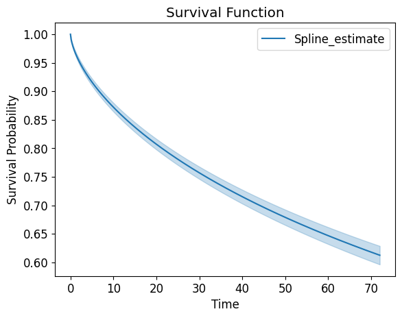

```python
# Plot the survival function
spline_fitter.plot_survival_function()
plt.title('Survival Function')
plt.xlabel('Time')
plt.ylabel('Survival Probability')
plt.show()
```

## Use QQ Plots for Model Selection

1. Fit parametric models using lifelines.
2. Plot the QQ plot for each model.
3. Choose the model with the QQ plot that is closest to y = x.

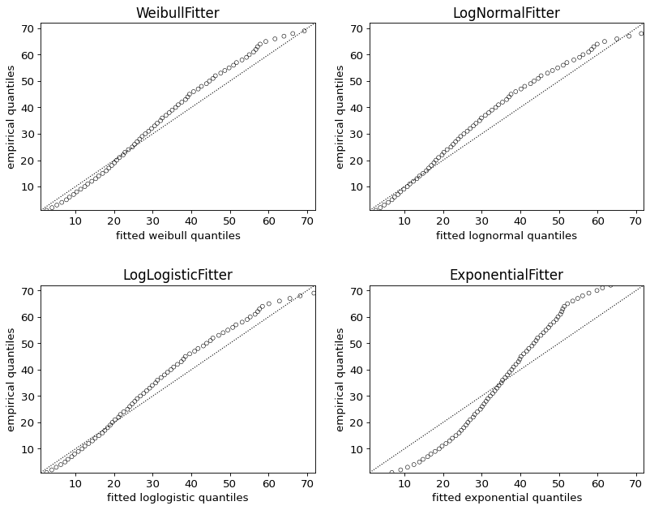

```python
font = {'size'   : 12}
plt.rc('font', **font)
fig, axs = plt.subplots(2, 2, figsize=(12, 9), dpi=80, facecolor='w', edgecolor='k')

ax1 = axs[0, 0]
model = WeibullFitter()
model.fit(T, E)
qq_plot(model, ax=ax1)
ax1.set_title("WeibullFitter",fontsize=15)

ax2 = axs[0, 1]
model = LogNormalFitter()
model.fit(T, E)
qq_plot(model, ax=ax2)
ax2.set_title("LogNormalFitter",fontsize=15)

ax3 = axs[1, 0]
model = LogLogisticFitter()
model.fit(T, E)
qq_plot(model, ax=ax3)
ax3.set_title("LogLogisticFitter",fontsize=15)


ax4 = axs[1, 1]
model = ExponentialFitter()
model.fit(T, E)
qq_plot(model, ax=ax4)
ax4.set_title("ExponentialFitter",fontsize=15)

plt.subplots_adjust(wspace=0.2)
plt.subplots_adjust(hspace=0.4)
plt.show()
```

# `CoxPHFitter` Package

The **hazard function** and **hazard rate** are key concepts in survival analysis, a branch of statistics that deals with analyzing the expected duration of time until one or more events happen, such as death in biological organisms or failure in mechanical systems.

**Hazard Function ($h(t)$)**

- The hazard function describes the instantaneous rate at which the event of interest is expected to happen at time $t$, given that the event has not yet occurred before time $t$.
- In simpler terms, the hazard function gives the rate at which the event is occurring at time $t$, provided that the subject has survived (or the event has not occurred) until time $t$.

**Hazard Rate**

- The hazard rate is synonymous with the hazard function. It is the instantaneous rate of event occurring

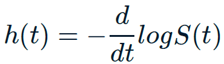

The **hazard function** $h(t)$ and the **survival function** $S(t)$ can be derived from each other.

The **proportional hazards assumption** is a key concept in the Cox proportional hazards model, which is widely used in survival analysis. This assumption states that the hazard functions for different individuals are proportional to each other over time. Here's a detailed explanation based on your points:

**Proportional Hazards Assumption**

- **Definition**: The proportional hazards assumption posits that the hazard function for any individual is a scaled version of the baseline hazard function. This means that for any two individuals, their hazard functions are proportional across time.

## Key Points

Consider two individuals, A and B, with hazard functions $h_A(t)$ and $h_B(t)$, respectively. According to the proportional hazards assumption, their relationship can be expressed as:

$h_A(t) = c \cdot h_B(t)$

where:

- $h_A(t)$ is the hazard function for individual A.
- $h_B(t)$ is the hazard function for individual B.
- $c$ is a positive constant (scaling factor) that does not depend on time $t$.

This implies that the ratio of the hazard functions for any two individuals is constant over time, i.e., the hazards are proportional.

### Assumption

1. **Baseline Hazard Function**:
   - The Cox model assumes the existence of a **baseline hazard function** $h_0(t)$ (changes over time), which represents the hazard for an individual with all covariates set to zero (or at their baseline levels).
   - For any individual $i$, the hazard function is modeled as: $h_i(t) = h_0(t) \cdot \exp(\beta_1 X_{i1} + \beta_2 X_{i2} + \dots + \beta_p X_{ip})$. The linear relationship between covariates and the log of hazard, does NOT change with time.

     where $X_{ij}$ are the covariates for individual $i$, and $\beta_j$ are the corresponding coefficients.
   - The hazards for different individuals differ by a multiplicative factor, $\exp(\beta_1 X_{i1} + \beta_2 X_{i2} + \dots + \beta_p X_{ip})$, but this factor is independent of time.
1. **Time-Invariance (Relative Survival Impact)**:
   - The **relative impact** of covariates on survival (the effect size represented by the coefficients ($\beta_j$) is **time-invariant**. This means that the effect of a covariate on the hazard rate does not change over time.
   - For instance, if smoking increases the hazard rate by a factor of 2, it does so consistently across all time points, not just at a specific time.

The Cox Proportional Hazards (Cox PH) model is a **regression** model that relates **covariates** to the time until an event occurs.

Data requirements for the Cox PH model include:

- **Durations**: The time or duration until the event occurs for each individual.
- **Events**: An indicator showing whether the event was observed (1 = Yes, 0 = No, censored). If this information is not provided, the model assumes that no subjects are censored.
- **Covariates**: Continuous variables or categorical variables that have been one-hot encoded for use in the regression.

## Fit Cox PH model

```python
coxph = CoxPHFitter(penalizer=0.1)
coxph.fit(train_set_time_label, duration_col='tenure', event_col='Churn', show_progress=True)
```

```
Iteration 1: norm_delta = 8.84e-01, step_size = 0.9500, log_lik = -12184.15103, newton_decrement = 1.39e+03, seconds_since_start = 0.0
Iteration 2: norm_delta = 2.81e-01, step_size = 0.9500, log_lik = -10779.98964, newton_decrement = 7.76e+01, seconds_since_start = 0.1
Iteration 3: norm_delta = 5.50e-02, step_size = 0.9500, log_lik = -10698.26734, newton_decrement = 2.26e+00, seconds_since_start = 0.1
Iteration 4: norm_delta = 1.50e-03, step_size = 1.0000, log_lik = -10695.96813, newton_decrement = 1.63e-03, seconds_since_start = 0.1
Iteration 5: norm_delta = 1.12e-06, step_size = 1.0000, log_lik = -10695.96650, newton_decrement = 9.01e-10, seconds_since_start = 0.2
Convergence success after 5 iterations.
```

```
<lifelines.CoxPHFitter: fitted with 5634 total observations, 4139 right-censored observations>
```

```python
coxph.print_summary()
```

| model | lifelines.CoxPHFitter |
| --- | --- |
| duration col | 'tenure' |
| event col | 'Churn' |
| penalizer | 0.1 |
| l1 ratio | 0.0 |
| baseline estimation | breslow |
| number of observations | 5634 |
| number of events observed | 1495 |
| partial log-likelihood | -10695.97 |
| time fit was run | 2024-08-15 03:25:50 UTC |

|  | coef | exp(coef) | se(coef) | coef lower 95% | coef upper 95% | exp(coef) lower 95% | exp(coef) upper 95% | cmp to | z | p | -log2(p) |
| --- | --- | --- | --- | --- | --- | --- | --- | --- | --- | --- | --- |
| MonthlyCharges | 0.00 | 1.00 | 0.00 | -0.00 | 0.00 | 1.00 | 1.00 | 0.00 | 1.67 | 0.10 | 3.38 |
| TotalCharges | -0.00 | 1.00 | 0.00 | -0.00 | -0.00 | 1.00 | 1.00 | 0.00 | -23.80 | <0.005 | 413.64 |
| gender_Female | 0.01 | 1.01 | 0.06 | -0.11 | 0.14 | 0.89 | 1.15 | 0.00 | 0.20 | 0.84 | 0.25 |
| gender_Male | -0.01 | 0.99 | 0.06 | -0.14 | 0.11 | 0.87 | 1.12 | 0.00 | -0.20 | 0.84 | 0.25 |
| SeniorCitizen_No | -0.00 | 1.00 | 0.09 | -0.17 | 0.17 | 0.84 | 1.18 | 0.00 | -0.00 | 1.00 | 0.01 |
| SeniorCitizen_Yes | 0.00 | 1.00 | 0.09 | -0.17 | 0.17 | 0.85 | 1.18 | 0.00 | 0.00 | 1.00 | 0.01 |
| Partner_No | 0.17 | 1.19 | 0.07 | 0.04 | 0.30 | 1.05 | 1.35 | 0.00 | 2.65 | 0.01 | 6.94 |
| Partner_Yes | -0.17 | 0.84 | 0.07 | -0.30 | -0.04 | 0.74 | 0.96 | 0.00 | -2.65 | 0.01 | 6.94 |
| Dependents_No | 0.06 | 1.06 | 0.07 | -0.09 | 0.20 | 0.92 | 1.22 | 0.00 | 0.76 | 0.45 | 1.16 |
| Dependents_Yes | -0.06 | 0.95 | 0.07 | -0.20 | 0.09 | 0.82 | 1.09 | 0.00 | -0.76 | 0.45 | 1.16 |
| PhoneService_No | -0.05 | 0.95 | 0.12 | -0.30 | 0.19 | 0.74 | 1.21 | 0.00 | -0.42 | 0.68 | 0.57 |
| PhoneService_Yes | 0.05 | 1.05 | 0.12 | -0.19 | 0.30 | 0.83 | 1.34 | 0.00 | 0.42 | 0.68 | 0.57 |
| MultipleLines_No | 0.11 | 1.12 | 0.06 | -0.01 | 0.24 | 0.99 | 1.27 | 0.00 | 1.76 | 0.08 | 3.67 |
| MultipleLines_No phone service | -0.05 | 0.95 | 0.12 | -0.30 | 0.19 | 0.74 | 1.21 | 0.00 | -0.42 | 0.68 | 0.57 |
| MultipleLines_Yes | -0.10 | 0.91 | 0.06 | -0.22 | 0.03 | 0.80 | 1.03 | 0.00 | -1.51 | 0.13 | 2.92 |
| InternetService_DSL | -0.23 | 0.79 | 0.07 | -0.37 | -0.10 | 0.69 | 0.91 | 0.00 | -3.33 | <0.005 | 10.19 |
| InternetService_Fiber optic | 0.30 | 1.34 | 0.07 | 0.16 | 0.43 | 1.17 | 1.54 | 0.00 | 4.27 | <0.005 | 15.65 |
| InternetService_No | -0.12 | 0.89 | 0.10 | -0.31 | 0.07 | 0.73 | 1.07 | 0.00 | -1.24 | 0.21 | 2.23 |
| OnlineSecurity_No | 0.27 | 1.31 | 0.07 | 0.14 | 0.40 | 1.15 | 1.49 | 0.00 | 3.98 | <0.005 | 13.80 |
| OnlineSecurity_No internet service | -0.12 | 0.89 | 0.10 | -0.31 | 0.07 | 0.73 | 1.07 | 0.00 | -1.24 | 0.21 | 2.23 |
| OnlineSecurity_Yes | -0.23 | 0.79 | 0.07 | -0.37 | -0.09 | 0.69 | 0.91 | 0.00 | -3.23 | <0.005 | 9.68 |
| OnlineBackup_No | 0.22 | 1.25 | 0.07 | 0.10 | 0.35 | 1.10 | 1.42 | 0.00 | 3.42 | <0.005 | 10.62 |
| OnlineBackup_No internet service | -0.12 | 0.89 | 0.10 | -0.31 | 0.07 | 0.73 | 1.07 | 0.00 | -1.24 | 0.21 | 2.23 |
| OnlineBackup_Yes | -0.15 | 0.86 | 0.07 | -0.29 | -0.02 | 0.75 | 0.98 | 0.00 | -2.29 | 0.02 | 5.52 |
| DeviceProtection_No | 0.14 | 1.16 | 0.07 | 0.02 | 0.27 | 1.02 | 1.31 | 0.00 | 2.20 | 0.03 | 5.15 |
| DeviceProtection_No internet service | -0.12 | 0.89 | 0.10 | -0.31 | 0.07 | 0.73 | 1.07 | 0.00 | -1.24 | 0.21 | 2.23 |
| DeviceProtection_Yes | -0.07 | 0.94 | 0.07 | -0.20 | 0.06 | 0.82 | 1.07 | 0.00 | -1.00 | 0.32 | 1.65 |
| TechSupport_No | 0.21 | 1.23 | 0.07 | 0.08 | 0.34 | 1.08 | 1.40 | 0.00 | 3.07 | <0.005 | 8.88 |
| TechSupport_No internet service | -0.12 | 0.89 | 0.10 | -0.31 | 0.07 | 0.73 | 1.07 | 0.00 | -1.24 | 0.21 | 2.23 |
| TechSupport_Yes | -0.15 | 0.86 | 0.07 | -0.29 | -0.01 | 0.75 | 0.99 | 0.00 | -2.14 | 0.03 | 4.96 |
| StreamingTV_No | 0.01 | 1.01 | 0.07 | -0.12 | 0.14 | 0.89 | 1.15 | 0.00 | 0.16 | 0.88 | 0.19 |
| StreamingTV_No internet service | -0.12 | 0.89 | 0.10 | -0.31 | 0.07 | 0.73 | 1.07 | 0.00 | -1.24 | 0.21 | 2.23 |
| StreamingTV_Yes | 0.08 | 1.08 | 0.07 | -0.05 | 0.21 | 0.95 | 1.23 | 0.00 | 1.16 | 0.24 | 2.03 |
| StreamingMovies_No | 0.05 | 1.05 | 0.07 | -0.08 | 0.17 | 0.92 | 1.19 | 0.00 | 0.70 | 0.48 | 1.05 |
| StreamingMovies_No internet service | -0.12 | 0.89 | 0.10 | -0.31 | 0.07 | 0.73 | 1.07 | 0.00 | -1.24 | 0.21 | 2.23 |
| StreamingMovies_Yes | 0.04 | 1.04 | 0.07 | -0.09 | 0.17 | 0.91 | 1.19 | 0.00 | 0.61 | 0.54 | 0.89 |
| Contract_Month-to-month | 0.73 | 2.08 | 0.07 | 0.60 | 0.87 | 1.82 | 2.38 | 0.00 | 10.76 | <0.005 | 87.35 |
| Contract_One year | -0.25 | 0.78 | 0.08 | -0.39 | -0.10 | 0.67 | 0.91 | 0.00 | -3.22 | <0.005 | 9.61 |
| Contract_Two year | -0.77 | 0.46 | 0.08 | -0.93 | -0.61 | 0.40 | 0.54 | 0.00 | -9.60 | <0.005 | 70.05 |
| PaperlessBilling_No | -0.11 | 0.90 | 0.07 | -0.24 | 0.02 | 0.79 | 1.03 | 0.00 | -1.59 | 0.11 | 3.15 |
| PaperlessBilling_Yes | 0.11 | 1.11 | 0.07 | -0.02 | 0.24 | 0.98 | 1.27 | 0.00 | 1.59 | 0.11 | 3.15 |
| PaymentMethod_Bank transfer (automatic) | -0.25 | 0.78 | 0.07 | -0.38 | -0.11 | 0.68 | 0.89 | 0.00 | -3.59 | <0.005 | 11.58 |
| PaymentMethod_Credit card (automatic) | -0.27 | 0.76 | 0.07 | -0.41 | -0.13 | 0.67 | 0.87 | 0.00 | -3.90 | <0.005 | 13.33 |
| PaymentMethod_Electronic check | 0.24 | 1.27 | 0.06 | 0.12 | 0.36 | 1.13 | 1.43 | 0.00 | 3.97 | <0.005 | 13.75 |
| PaymentMethod_Mailed check | 0.20 | 1.22 | 0.07 | 0.06 | 0.33 | 1.06 | 1.39 | 0.00 | 2.86 | <0.005 | 7.89 |

| Concordance | 0.90 |
| --- | --- |
| Partial AIC | 21481.93 |
| log-likelihood ratio test | 2976.37 on 45 df |
| -log2(p) of ll-ratio test | inf |

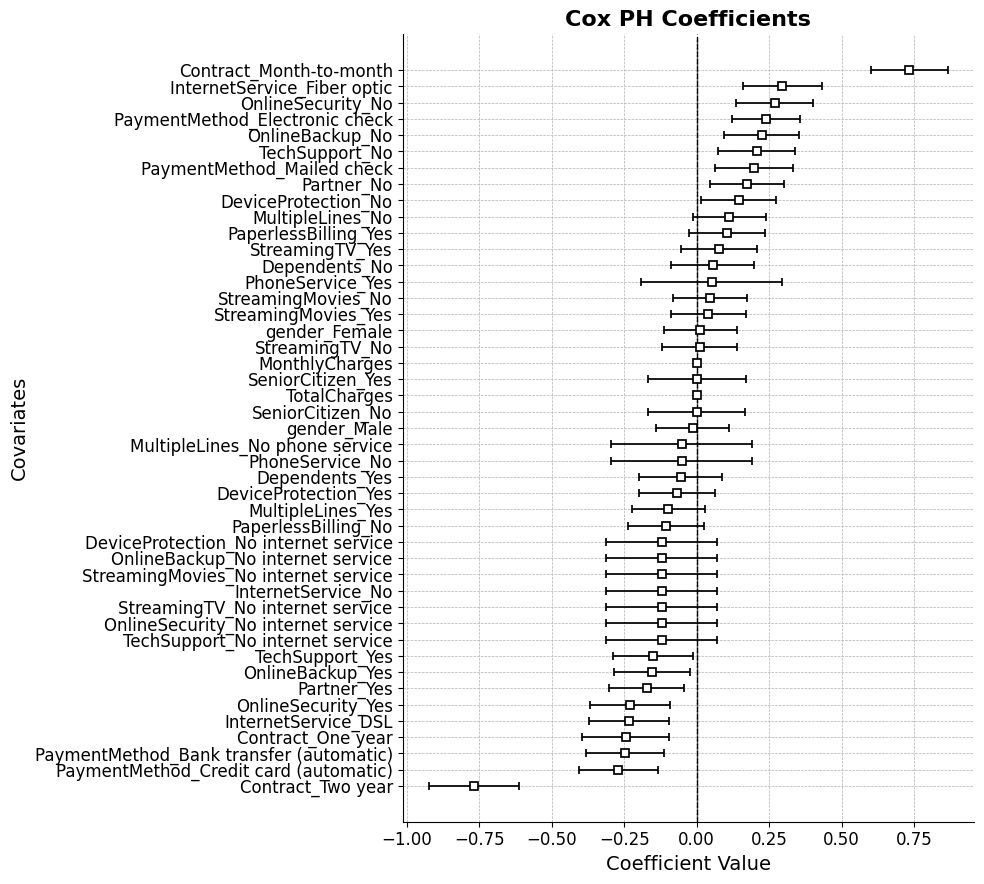

```python
fig, ax = plt.subplots(figsize=(10, 9))  # Set the figure size

coxph.plot()

# Beautify the plot
ax.set_title("Cox PH Coefficients", fontsize=16, fontweight='bold')
ax.set_xlabel("Coefficient Value", fontsize=14)
ax.set_ylabel("Covariates", fontsize=14)
ax.grid(True, linestyle='--', linewidth=0.5)  # Add a grid with custom style
ax.axvline(x=0, color='k', linestyle='--', linewidth=1)  # Add a vertical line at x=0
ax.spines['top'].set_visible(False)  # Hide the top spine
ax.spines['right'].set_visible(False)  # Hide the right spine

# Customize tick parameters
ax.tick_params(axis='x', which='both', bottom=True, top=False, labelbottom=True)
ax.tick_params(axis='y', which='both', left=True, right=False, labelleft=True)

plt.tight_layout()  # Adjust subplots to fit into figure area.

# Show the plot
plt.show()
```

### How to Interpret coefficients

**Coefficient Sign**

- **Positive Coefficient**:
  - Indicates that as the covariate increases, the hazard of the event occurring increases.
  - The individual is at a higher risk of experiencing the event sooner.
- **Negative Coefficient**:
  - Indicates that as the covariate increases, the hazard of the event decreases.
  - The individual is at a lower risk of experiencing the event, implying longer survival or delay in the event occurrence.
- **Zero Coefficient**:
  - Indicates no effect of the covariate on the hazard rate.

**Hazard Ratio (HR)**:

- How much hazard increases or decreases relative to baseline hazards. The hazard ratio is calculated as $e^{beta}$, where $\beta$ is the coefficient.
- **Interpreting the Hazard Ratio**:
  - **HR > 1**: Indicates an increased hazard (higher risk) associated with the covariate. For example, if $\beta = 0.7 $, then $HR = e^{0.7} \approx 2.01$, meaning the hazard is twice as high for individuals with a one-unit increase in the covariate.
  - **HR < 1**: Indicates a decreased hazard (lower risk). For example, if $\beta = -0.5$, then $HR = e^{-0.5} \approx 0.6$, meaning the hazard is reduced by about 39% with a one-unit increase in the covariate.
  - **HR = 1**: Suggests no effect of the covariate on the hazard.

[output not shown]

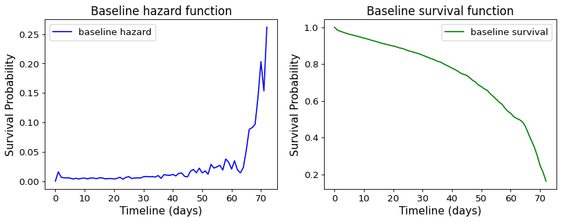

```python
import matplotlib.pyplot as plt

font = {'size': 12}
plt.rc('font', **font)

fig, axs = plt.subplots(1, 2, figsize=(12, 4), dpi=80, facecolor='w', edgecolor='k')

ax1 = axs[0]
coxph.baseline_hazard_.plot(ax=ax1, color='blue')
ax1.set_title("Baseline hazard function", fontsize=15)
ax1.set_xlabel("Timeline (days)", fontsize=14)
ax1.set_ylabel("Survival Probability", fontsize=14)
ax1.tick_params(axis='x', which='both', bottom=True, top=False, labelbottom=True)
ax1.tick_params(axis='y', which='both', left=True, right=False, labelleft=True)

ax2 = axs[1]
coxph.baseline_survival_.plot(ax=ax2, color='green')
ax2.set_title("Baseline survival function", fontsize=15)
ax2.set_xlabel("Timeline (days)", fontsize=14)
ax2.set_ylabel("Survival Probability", fontsize=14)
ax2.tick_params(axis='x', which='both', bottom=True, top=False, labelbottom=True)
ax2.tick_params(axis='y', which='both', left=True, right=False, labelleft=True)

plt.subplots_adjust(wspace=0.2, hspace=0.4)
plt.show()
```

## Visualize the Hazard Ratio

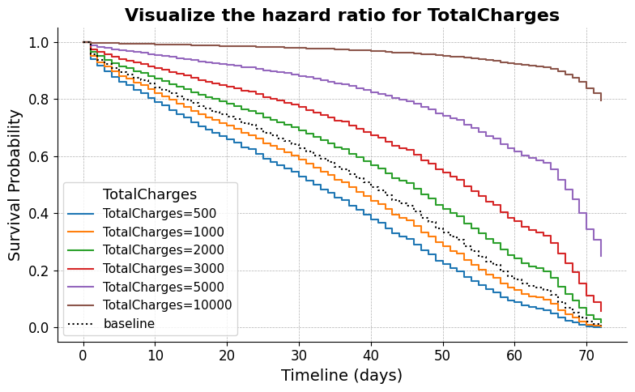

```python
# Plot partial effects on outcome
fig, ax = plt.subplots(figsize=(8, 5))  # Set the figure size

coxph.plot_partial_effects_on_outcome(covariates=["TotalCharges"],
                                      values=[500, 1000, 2000, 3000, 5000, 10000],ax=ax)
# Beautify the plot
ax.set_title("Visualize the hazard ratio for TotalCharges", fontsize=16, fontweight='bold')
ax.set_xlabel("Timeline (days)", fontsize=14)
ax.set_ylabel("Survival Probability", fontsize=14)
ax.grid(True, linestyle='--', linewidth=0.5)  # Add a grid with custom style
ax.spines['top'].set_visible(False)  # Hide the top spine
ax.spines['right'].set_visible(False)  # Hide the right spine

# Customize tick parameters
ax.tick_params(axis='x', which='both', bottom=True, top=False, labelbottom=True)
ax.tick_params(axis='y', which='both', left=True, right=False, labelleft=True)

plt.legend(title="TotalCharges", title_fontsize='13', fontsize='11')  # Customize the legend

plt.tight_layout()  # Adjust subplots to fit into figure area

# Show the plot
plt.show()
```

## Cross Validation

```python
import numpy as np
from lifelines import AalenAdditiveFitter, CoxPHFitter
from lifelines.datasets import load_regression_dataset
from lifelines.utils import k_fold_cross_validation

df = load_regression_dataset()

#create the three models we'd like to compare.
aaf_1 = AalenAdditiveFitter(coef_penalizer=0.5)
aaf_2 = AalenAdditiveFitter(coef_penalizer=10)
cph = CoxPHFitter()

print(np.mean(k_fold_cross_validation(cph, df, duration_col='T', event_col='E', scoring_method="concordance_index")))
print(np.mean(k_fold_cross_validation(aaf_1, df, duration_col='T', event_col='E', scoring_method="concordance_index")))
print(np.mean(k_fold_cross_validation(aaf_2, df, duration_col='T', event_col='E', scoring_method="concordance_index")))
```

```
0.5590243798738769
0.5644669239008682
0.5726651568632664
```

## How to Use the Kaplan-Meier curves

- **Kaplan-Meier Curves** are used in survival analysis to estimate the survival function, which shows the probability of an event (like death or failure) occurring over time.
- These curves are typically plotted for different groups within your data, where each group corresponds to different values of a covariate (independent variable).
- **Covariate with Few Values**: If your covariate (e.g., a variable like treatment type, gender, etc.) only has a few distinct values or categories, it's feasible to create and inspect Kaplan-Meier curves for each group separately.
- For example, if you have a binary covariate (e.g., "Treatment A" vs. "Treatment B"), you would plot a Kaplan-Meier curve for each treatment group.
- **Curves Intersecting**: When you inspect these Kaplan-Meier curves, you might observe that they intersect at some points. This means that the survival probabilities for the different groups cross each other over time.
- **Intersection of Curves**: If the curves intersect, it indicates that the relative risk (or hazard) between the groups is not consistent over time. For example, one group might have a higher survival probability at the beginning, but this advantage may decrease or even reverse as time goes on. In this case, the proportional hazards assumption fails.

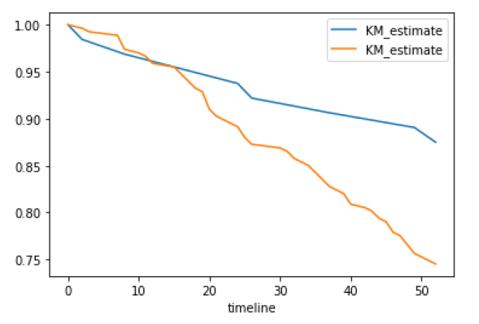

- If curves have similar shapes and are parallel: the proportional hazards assumption **satisfies**.

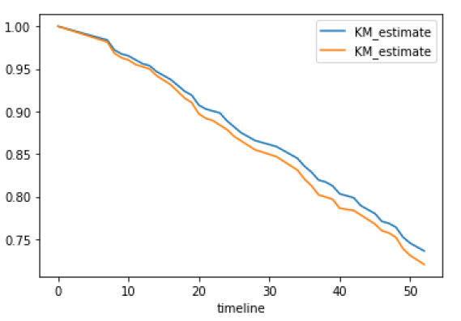

For continuous covariates, we can use the `.check_assumptions()` method as below:

```python
coxph.check_assumptions(train_set_time_label, p_value_threshold=0.05)
```

```
The ``p_value_threshold`` is set at 0.05. Even under the null hypothesis of no violations, some
covariates will be below the threshold by chance. This is compounded when there are many covariates.
Similarly, when there are lots of observations, even minor deviances from the proportional hazard
assumption will be flagged.

With that in mind, it's best to use a combination of statistical tests and visual tests to determine
the most serious violations. Produce visual plots using ``check_assumptions(..., show_plots=True)``
and looking for non-constant lines. See link [A] below for a full example.
```

| null_distribution | chi squared |
| --- | --- |
| degrees_of_freedom | 1 |
| model | <lifelines.CoxPHFitter: fitted with 5634 total observations, 4139 right-censored observations> |
| test_name | proportional_hazard_test |

|  |  | test_statistic | p | -log2(p) |
| --- | --- | --- | --- | --- |
| Contract_Month-to-month | km | 0.00 | 0.97 | 0.05 |
|  | rank | 0.00 | 0.96 | 0.05 |
| Contract_One year | km | 16.36 | <0.005 | 14.22 |
|  | rank | 11.24 | <0.005 | 10.29 |
| Contract_Two year | km | 11.30 | <0.005 | 10.33 |
|  | rank | 8.30 | <0.005 | 7.98 |
| Dependents_No | km | 0.07 | 0.80 | 0.33 |
|  | rank | 0.04 | 0.84 | 0.24 |
| Dependents_Yes | km | 0.07 | 0.80 | 0.33 |
|  | rank | 0.04 | 0.84 | 0.24 |
| DeviceProtection_No | km | 0.01 | 0.93 | 0.10 |
|  | rank | 0.00 | 0.95 | 0.07 |
| DeviceProtection_No internet service | km | 0.67 | 0.41 | 1.28 |
|  | rank | 0.71 | 0.40 | 1.33 |
| DeviceProtection_Yes | km | 0.99 | 0.32 | 1.65 |
|  | rank | 0.99 | 0.32 | 1.65 |
| InternetService_DSL | km | 1.11 | 0.29 | 1.78 |
|  | rank | 1.21 | 0.27 | 1.88 |
| InternetService_Fiber optic | km | 3.12 | 0.08 | 3.69 |
|  | rank | 3.35 | 0.07 | 3.89 |
| InternetService_No | km | 0.67 | 0.41 | 1.28 |
|  | rank | 0.71 | 0.40 | 1.33 |
| MonthlyCharges | km | 3.59 | 0.06 | 4.11 |
|  | rank | 3.96 | 0.05 | 4.42 |
| MultipleLines_No | km | 0.70 | 0.40 | 1.31 |
|  | rank | 0.97 | 0.32 | 1.62 |
| MultipleLines_No phone service | km | 0.35 | 0.56 | 0.85 |
|  | rank | 0.45 | 0.50 | 0.99 |
| MultipleLines_Yes | km | 1.53 | 0.22 | 2.21 |
|  | rank | 2.09 | 0.15 | 2.75 |

[output cut: 60 more lines]

```
1. Variable 'MonthlyCharges' failed the non-proportional test: p-value is 0.0466.

   Advice 1: the functional form of the variable 'MonthlyCharges' might be incorrect. That is, there
may be non-linear terms missing. The proportional hazard test used is very sensitive to incorrect
functional forms. See documentation in link [D] below on how to specify a functional form.

   Advice 2: try binning the variable 'MonthlyCharges' using pd.cut, and then specify it in
`strata=['MonthlyCharges', ...]` in the call in `.fit`. See documentation in link [B] below.

   Advice 3: try adding an interaction term with your time variable. See documentation in link [C]
below.


2. Variable 'Contract_One year' failed the non-proportional test: p-value is 0.0001.

   Advice: with so few unique values (only 2), you can include `strata=['Contract_One year', ...]`
in the call in `.fit`. See documentation in link [E] below.

3. Variable 'Contract_Two year' failed the non-proportional test: p-value is 0.0008.

   Advice: with so few unique values (only 2), you can include `strata=['Contract_Two year', ...]`
in the call in `.fit`. See documentation in link [E] below.

---
[A]  https://lifelines.readthedocs.io/en/latest/jupyter_notebooks/Proportional%20hazard%20assumption.html
[B]  https://lifelines.readthedocs.io/en/latest/jupyter_notebooks/Proportional%20hazard%20assumption.html#Bin-variable-and-stratify-on-it
[C]  https://lifelines.readthedocs.io/en/latest/jupyter_notebooks/Proportional%20hazard%20assumption.html#Introduce-time-varying-covariates
[D]  https://lifelines.readthedocs.io/en/latest/jupyter_notebooks/Proportional%20hazard%20assumption.html#Modify-the-functional-form
[E]  https://lifelines.readthedocs.io/en/latest/jupyter_notebooks/Proportional%20hazard%20assumption.html#Stratification
```

```
[]
```

If the assumption fails, consider using alternative modeling frameworks, like the Weibull AFT model, and compare their AIC scores.

# Prediction with the Cox PH Model

1. **Model Fitting (`.fit()`)**:
   - Before predicting survival times, the model must first be trained on your survival data. This is done using the `.fit()` method, which takes your training data (usually a DataFrame containing features and survival times) and fits the model to it.
1. **Prediction of Median Survival Times (`.predict_median()`)**:
   - Once the model is fitted, you can use the `.predict_median()` method to predict the median survival times for new subjects (i.e., those not in the training set).
   - **Median Lifetime**: In survival analysis, the median lifetime is the time at which the probability of survival is 0.5, meaning that half of the subjects are expected to have survived up to that point, and half are expected to have died.
1. **Behavior When the Survival Curve Does Not Cross 0.5**:
   - The survival curve represents the probability of survival over time. If the survival curve for a subject never drops to 0.5 (e.g., if the probability of survival remains higher than 0.5 throughout the observation period), the median survival time is considered infinite (`inf`). This indicates that more than half of the subjects are expected to survive beyond the observed time frame.

**Parameters**

- **`X`**:
  - This is the DataFrame containing the data for which you want to predict the median survival times. The DataFrame should include the same features used in the model training.
- **`conditional_after`**:
  - This parameter is an array or list that specifies how long the subjects have already lived. It represents the "conditional" survival time; in other words, if a subject has already survived a certain amount of time, the prediction is based on their survival from that point forward.
  - For example, if a subject has already survived 2 years, the prediction would estimate how much longer they are expected to live, conditional on having survived those 2 years.

In summary, `.predict_median()` is a method used in survival models to estimate the median survival time for subjects, taking into account any time they've already survived, and it handles cases where the median survival time might be infinite.

```python
test_set_strat_time_label.head()
```

| customerID | MonthlyCharges | TotalCharges | gender_Female | gender_Male | SeniorCitizen_No | SeniorCitizen_Yes | Partner_No | Partner_Yes | Dependents_No | Dependents_Yes | PhoneService_No | PhoneService_Yes | MultipleLines_No | MultipleLines_No phone service | MultipleLines_Yes | InternetService_DSL | InternetService_Fiber optic | InternetService_No | OnlineSecurity_No | OnlineSecurity_No internet service | OnlineSecurity_Yes | OnlineBackup_No | OnlineBackup_No internet service | OnlineBackup_Yes | DeviceProtection_No | DeviceProtection_No internet service | DeviceProtection_Yes | TechSupport_No | TechSupport_No internet service | … |
| --- | --- | --- | --- | --- | --- | --- | --- | --- | --- | --- | --- | --- | --- | --- | --- | --- | --- | --- | --- | --- | --- | --- | --- | --- | --- | --- | --- | --- | --- | --- |
| 0023-UYUPN | 25.20 | 1306.30 | 1.0 | 0.0 | 0.0 | 1.0 | 0.0 | 1.0 | 1.0 | 0.0 | 0.0 | 1.0 | 0.0 | 0.0 | 1.0 | 0.0 | 0.0 | 1.0 | 0.0 | 1.0 | 0.0 | 0.0 | 1.0 | 0.0 | 0.0 | 1.0 | 0.0 | 0.0 | 1.0 | … |
| 7610-TVOPG | 26.35 | 378.60 | 0.0 | 1.0 | 1.0 | 0.0 | 1.0 | 0.0 | 1.0 | 0.0 | 0.0 | 1.0 | 0.0 | 0.0 | 1.0 | 0.0 | 0.0 | 1.0 | 0.0 | 1.0 | 0.0 | 0.0 | 1.0 | 0.0 | 0.0 | 1.0 | 0.0 | 0.0 | 1.0 | … |
| 8050-DVOJX | 81.35 | 4060.90 | 0.0 | 1.0 | 0.0 | 1.0 | 1.0 | 0.0 | 1.0 | 0.0 | 0.0 | 1.0 | 0.0 | 0.0 | 1.0 | 1.0 | 0.0 | 0.0 | 0.0 | 0.0 | 1.0 | 0.0 | 0.0 | 1.0 | 0.0 | 0.0 | 1.0 | 0.0 | 0.0 | … |
| 8189-DUKMV | 20.50 | 79.05 | 1.0 | 0.0 | 1.0 | 0.0 | 0.0 | 1.0 | 1.0 | 0.0 | 0.0 | 1.0 | 1.0 | 0.0 | 0.0 | 0.0 | 0.0 | 1.0 | 0.0 | 1.0 | 0.0 | 0.0 | 1.0 | 0.0 | 0.0 | 1.0 | 0.0 | 0.0 | 1.0 | … |
| 2911-WDXMV | 80.55 | 1406.65 | 0.0 | 1.0 | 1.0 | 0.0 | 1.0 | 0.0 | 0.0 | 1.0 | 0.0 | 1.0 | 0.0 | 0.0 | 1.0 | 0.0 | 1.0 | 0.0 | 1.0 | 0.0 | 0.0 | 1.0 | 0.0 | 0.0 | 0.0 | 0.0 | 1.0 | 1.0 | 0.0 | … |

```python
coxph.predict_median(test_set_strat_time_label)
```

```
0023-UYUPN     inf
7610-TVOPG    51.0
8050-DVOJX     inf
8189-DUKMV     inf
2911-WDXMV    28.0
              ...
8777-PVYGU    71.0
6519-CFDBX    10.0
6384-VMJHP     inf
3441-CGZJH     inf
5274-XHAKY    67.0
Name: 0.5, Length: 1409, dtype: float64
```

```python
uncensored_tenure_test = test_set_strat_time_label[test_set_strat_time_label.Churn==1]
```

```python
x = uncensored_tenure_test.tenure.values
y = coxph.predict_median(uncensored_tenure_test).values
#
x = x[np.isfinite(y)]
y = y[np.isfinite(y)]

mae = mean_absolute_error(x, y)
print(f"Mean Absolute Error: {mae}")
```

```
Mean Absolute Error: 13.485549208092484
```

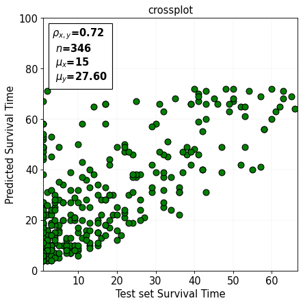

```python
font = {'size'   : 12}
plt.rc('font', **font)
fig, ax1 = plt.subplots(figsize=(6, 6), dpi= 80, facecolor='w', edgecolor='k')

CrossPlot(x,y,title=f'crossplot',
          xlabl='Test set Survival Time',
          ylabl='Predicted Survival Time',
          loc=2,
          xlimt=(np.nanmin(x)-np.nanmin(x)*0.01,np.nanmax(x)+np.nanmax(x)*0.01),
          ylimt=(0, 100),
          axt=ax1,
          scale=1.1,
          alpha=1,
          fit_=False,
          markersize=8,
          marker='o',
          color='g',
          markeredgecolor='black')


plt.show()
```

Measuring the performance of a survival analysis model on a test set involves evaluating how well the model predicts survival times or survival probabilities. **Concordance Index (C-Index)** is widely used and provides a good measure of the model's discriminative ability:

## **Concordance Index (C-Index)**

- **Definition**: The C-index measures the model's ability to correctly rank pairs of subjects based on their predicted survival times. It's akin to the area under the ROC curve (AUC) for binary classification.
- **Interpretation**:
  - A C-index of 0.5 indicates random predictions (no predictive power).
  - A C-index of 1.0 indicates perfect predictive accuracy.
- **Calculation**:
  - For a pair of subjects, if one subject is observed to survive longer than the other, the model's predictions are considered concordant if it also predicts a longer survival time for the first subject. The C-index is the proportion of all pairs that are concordant.

  ```
  from lifelines.utils import concordance_index
  c_index = concordance_index(test_data["time"], model.predict(test_data), test_data["event"])
  ```

```python
from lifelines.utils import concordance_index
c_index = concordance_index(test_set_strat_time_label["tenure"],
                            coxph.predict_median(test_set_strat_time_label), test_set_strat_time_label["Churn"])
```

```python
c_index
```

```
0.9005230055534491
```

```python
#aft.predict_survival_function(test_set_strat_time_label.iloc[0], conditional_after=10)
customer_1= coxph.predict_survival_function(test_set_strat_time_label.iloc[0])
customer_2= coxph.predict_survival_function(test_set_strat_time_label.iloc[10])
customer_3= coxph.predict_survival_function(test_set_strat_time_label.iloc[20])
customer_4= coxph.predict_survival_function(test_set_strat_time_label.iloc[30])
customer_1.head()
```

|  | 0023-UYUPN |
| --- | --- |
| 1.000000e-07 | 1.000000 |
| 1.000000e+00 | 0.995600 |
| 2.000000e+00 | 0.993766 |
| 3.000000e+00 | 0.992209 |
| 4.000000e+00 | 0.990654 |

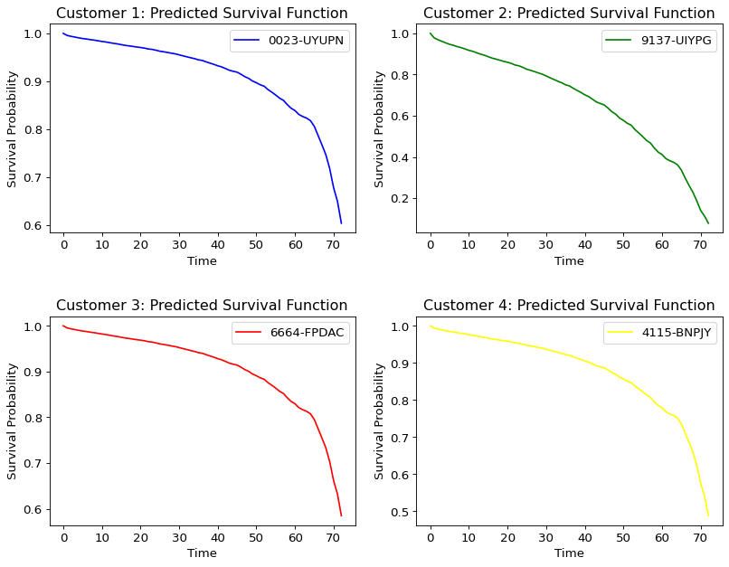

```python
font = {'size'   : 12}
plt.rc('font', **font)
fig, axs = plt.subplots(2, 2, figsize=(12, 9), dpi=80, facecolor='w', edgecolor='k')

ax1 = axs[0, 0]
customer_1.plot(ax=ax1, color='blue')
ax1.set_title("Customer 1: Predicted Survival Function")
ax1.set_xlabel("Time")
ax1.set_ylabel("Survival Probability")

#
ax2 = axs[0, 1]
customer_2.plot(ax=ax2, color='green')
ax2.set_title("Customer 2: Predicted Survival Function")
ax2.set_xlabel("Time")
ax2.set_ylabel("Survival Probability")

#
ax3 = axs[1, 0]
customer_3.plot(ax=ax3, color='red')
ax3.set_title("Customer 3: Predicted Survival Function")
ax3.set_xlabel("Time")
ax3.set_ylabel("Survival Probability")

#
ax4 = axs[1, 1]
customer_4.plot(ax=ax4, color='yellow')
ax4.set_title("Customer 4: Predicted Survival Function")
ax4.set_xlabel("Time")
ax4.set_ylabel("Survival Probability")
#
plt.subplots_adjust(wspace=0.2)
plt.subplots_adjust(hspace=0.4)
plt.show()
```

**Why are survival predictions useful?**

- Enable proactive failure prevention and enhance forecasting models.
- Estimate the time until an event occurs.
- Assess how various factors influence the timing of events.